# CASE_STUDY_2

AndrewMejia

4/1/2020

**Project introduction: A data set of attrition and monthly income was provided, in order to predict attrition for a client, Frito-Lay. Another analysis was performed to identify monthly income for a set of unlabled observations.**

**Scope of inference, as we do not know how the data was colleceted, any predictions beyond this data set are purely extrapolation.**

**Executive Summary: The purpose of this analysis was to explore the top three factors leading to attrition as well as explore the top three factors leading to monthly income.**

**The identified factors for Attrition are as follows** **1. Job Role** **2. Distance Frome Home** **3. Number of Companies Worked**

**Really would want to review the HR job odds ratio, odds of attriting is 8.55 e+6 times over the odds of staying.**

**The identified factors for Monthly Income are as follows** **1. Total Working Years** **2. Job Role** **3. Job Level**

**The recomended model for predicting attrition is a logsitic regression model using the following predictors** **Age + DailyRate + Department + Education +** **EducationField + JobLevel + JobSatisfaction + MaritalStatus +** **YearsInCurrentRole + OverTime + JobRole + JobInvolvement +** **YearsSinceLastPromotion + EnvironmentSatisfaction + DistanceFromHome +** **NumCompaniesWorked + WorkLifeBalance + PerformanceRating +** **HourlyRate + TotalWorkingYears + YearsAtCompany + MonthlyIncome +** **BusinessTravel + YearsWithCurrManager + RelationshipSatisfaction +** **PercentSalaryHike + EmployeeNumber**

**The recommended model for predicting monthly income is a linear model using the following predictors** **TotalWorkingYears + JobLevel + JobRole + MonthlyRate + Gender + EmployeeNumber**

**Video Link:** __https://youtu.be/sJqT7rTYkPg__

**There are two prediction output files in this repo.** **1.Case2PredictionsMejiaAttrition.csv** **2.Case2PredictionsMejiaSalary.csv**

#Loading the required libraries

```r
library(ggplot2)
library(GGally)
library(dplyr)
library(caret)
library(plotly)
library(tidyverse)
library(class)
library(e1071)
library(nnet)
library(GGally)
library(MASS)
library(car)
library(knitr)
library(pander)
library(broom)
library(scatterplot3d)
library(DataCombine)
library(corrplot)
library(kableExtra)
library(lubridate)
library(stringr)
library(sjPlot)
library(gmodels)
library(inspectdf)
library(ggmosaic)
library(cowplot)
library(ResourceSelection)
```

```
## ResourceSelection 0.3-5   2019-07-22
```

```r
case_study_2  = read.csv('/media/andrew/29426984-e707-487c-8f66-ca5e368b23d11/Documents/School/HomeWork/DS6306_DDS/MSDS_6306_Doing-Data-Science/Unit 14 and 15 Case Study 2/CaseStudy2-data.csv',header = TRUE)
#case_study_2['Log_ML_IN'] = log(case_study_2$MonthlyIncome)

case_study_salary_preds  = read.csv('/media/andrew/29426984-e707-487c-8f66-ca5e368b23d11/Documents/School/HomeWork/DS6306_DDS/MSDS_6306_Doing-Data-Science/Unit 14 and 15 Case Study 2/CaseStudy2CompSet No Salary.csv',header = TRUE)

case_study_attrition_preds = read.csv('/media/andrew/29426984-e707-487c-8f66-ca5e368b23d11/Documents/School/HomeWork/DS6306_DDS/MSDS_6306_Doing-Data-Science/Unit 14 and 15 Case Study 2/CaseStudy2CompSet No Attrition.csv',header = TRUE)

summary(case_study_2)
```

```
##        ID             Age        Attrition           BusinessTravel
##  Min.   :  1.0   Min.   :18.00   No :730   Non-Travel       : 94
##  1st Qu.:218.2   1st Qu.:30.00   Yes:140   Travel_Frequently:158
##  Median :435.5   Median :35.00             Travel_Rarely    :618
##  Mean   :435.5   Mean   :36.83
##  3rd Qu.:652.8   3rd Qu.:43.00
##  Max.   :870.0   Max.   :60.00
##
##    DailyRate                       Department  DistanceFromHome   Education
##  Min.   : 103.0   Human Resources       : 35   Min.   : 1.000   Min.   :1.000
##  1st Qu.: 472.5   Research & Development:562   1st Qu.: 2.000   1st Qu.:2.000
##  Median : 817.5   Sales                 :273   Median : 7.000   Median :3.000
##  Mean   : 815.2                                Mean   : 9.339   Mean   :2.901
##  3rd Qu.:1165.8                                3rd Qu.:14.000   3rd Qu.:4.000
##  Max.   :1499.0                                Max.   :29.000   Max.   :5.000
##
##           EducationField EmployeeCount EmployeeNumber   EnvironmentSatisfaction
##  Human Resources : 15    Min.   :1     Min.   :   1.0   Min.   :1.000
##  Life Sciences   :358    1st Qu.:1     1st Qu.: 477.2   1st Qu.:2.000
##  Marketing       :100    Median :1     Median :1039.0   Median :3.000
##  Medical         :270    Mean   :1     Mean   :1029.8   Mean   :2.701
##  Other           : 52    3rd Qu.:1     3rd Qu.:1561.5   3rd Qu.:4.000
##  Technical Degree: 75    Max.   :1     Max.   :2064.0   Max.   :4.000
##
##     Gender      HourlyRate     JobInvolvement     JobLevel
##  Female:354   Min.   : 30.00   Min.   :1.000   Min.   :1.000
##  Male  :516   1st Qu.: 48.00   1st Qu.:2.000   1st Qu.:1.000
##               Median : 66.00   Median :3.000   Median :2.000
##               Mean   : 65.61   Mean   :2.723   Mean   :2.039
##               3rd Qu.: 83.00   3rd Qu.:3.000   3rd Qu.:3.000
##               Max.   :100.00   Max.   :4.000   Max.   :5.000
##
##                       JobRole    JobSatisfaction  MaritalStatus MonthlyIncome
##  Sales Executive          :200   Min.   :1.000   Divorced:191   Min.   : 1081
##  Research Scientist       :172   1st Qu.:2.000   Married :410   1st Qu.: 2840
##  Laboratory Technician    :153   Median :3.000   Single  :269   Median : 4946
##  Manufacturing Director   : 87   Mean   :2.709                  Mean   : 6390
##  Healthcare Representative: 76   3rd Qu.:4.000                  3rd Qu.: 8182
##  Sales Representative     : 53   Max.   :4.000                  Max.   :19999
##  (Other)                  :129
```

[output cut: 17 more lines]

```
##  Min.   : 0.00     Min.   :0.000         Min.   :1.000   Min.   : 0.000
##  1st Qu.: 6.00     1st Qu.:2.000         1st Qu.:2.000   1st Qu.: 3.000
##  Median :10.00     Median :3.000         Median :3.000   Median : 5.000
##  Mean   :11.05     Mean   :2.832         Mean   :2.782   Mean   : 6.962
##  3rd Qu.:15.00     3rd Qu.:3.000         3rd Qu.:3.000   3rd Qu.:10.000
##  Max.   :40.00     Max.   :6.000         Max.   :4.000   Max.   :40.000
##
##  YearsInCurrentRole YearsSinceLastPromotion YearsWithCurrManager
##  Min.   : 0.000     Min.   : 0.000          Min.   : 0.00
##  1st Qu.: 2.000     1st Qu.: 0.000          1st Qu.: 2.00
##  Median : 3.000     Median : 1.000          Median : 3.00
##  Mean   : 4.205     Mean   : 2.169          Mean   : 4.14
##  3rd Qu.: 7.000     3rd Qu.: 3.000          3rd Qu.: 7.00
##  Max.   :18.000     Max.   :15.000          Max.   :17.00
##
```

```r
# We see there is a highly Imbalanced data set
table(case_study_2$Attrition)
```

```
##
##  No Yes
## 730 140
```

```r
na_indx = apply(case_study_2, 2, function(x) any(is.na(x) | is.infinite(x)))
na_indx
```

```
##                       ID                      Age                Attrition
##                    FALSE                    FALSE                    FALSE
##           BusinessTravel                DailyRate               Department
##                    FALSE                    FALSE                    FALSE
##         DistanceFromHome                Education           EducationField
##                    FALSE                    FALSE                    FALSE
##            EmployeeCount           EmployeeNumber  EnvironmentSatisfaction
##                    FALSE                    FALSE                    FALSE
##                   Gender               HourlyRate           JobInvolvement
##                    FALSE                    FALSE                    FALSE
##                 JobLevel                  JobRole          JobSatisfaction
##                    FALSE                    FALSE                    FALSE
##            MaritalStatus            MonthlyIncome              MonthlyRate
##                    FALSE                    FALSE                    FALSE
##       NumCompaniesWorked                   Over18                 OverTime
##                    FALSE                    FALSE                    FALSE
##        PercentSalaryHike        PerformanceRating RelationshipSatisfaction
##                    FALSE                    FALSE                    FALSE
##            StandardHours         StockOptionLevel        TotalWorkingYears
##                    FALSE                    FALSE                    FALSE
##    TrainingTimesLastYear          WorkLifeBalance           YearsAtCompany
##                    FALSE                    FALSE                    FALSE
##       YearsInCurrentRole  YearsSinceLastPromotion     YearsWithCurrManager
##                    FALSE                    FALSE                    FALSE
```

```r
attach(case_study_2)
```

**EDA**

```r
#EDA for attributes  leading to attritition


#Wanting to look at proportion tables for EDA to see largest shifts for model inclusions
categorical_variables = case_study_2 %>% select_if(is.factor) %>% names()


# remove the response
response_ind = match('Attrition', categorical_variables)
categorical_variables = categorical_variables[-response_ind]


# plot categorical variables
for (i in categorical_variables) {

print(i)
  CrossTable(case_study_2[, i], case_study_2[,"Attrition"],
             prop.r = T,
             prop.c = F,
             prop.t = F,
             prop.chisq = F,
             dnn = c(i, "Attrition"))




}
```

```
## [1] "BusinessTravel"
##
##
##    Cell Contents
## |-------------------------|
## |                       N |
## |           N / Row Total |
## |-------------------------|
##
##
## Total Observations in Table:  870
##
##
##                   | Attrition
##    BusinessTravel |        No |       Yes | Row Total |
## ------------------|-----------|-----------|-----------|
##        Non-Travel |        83 |        11 |        94 |
##                   |     0.883 |     0.117 |     0.108 |
## ------------------|-----------|-----------|-----------|
## Travel_Frequently |       123 |        35 |       158 |
##                   |     0.778 |     0.222 |     0.182 |
## ------------------|-----------|-----------|-----------|
##     Travel_Rarely |       524 |        94 |       618 |
##                   |     0.848 |     0.152 |     0.710 |
## ------------------|-----------|-----------|-----------|
##      Column Total |       730 |       140 |       870 |
## ------------------|-----------|-----------|-----------|
##
##
## [1] "Department"
##
##
##    Cell Contents
## |-------------------------|
## |                       N |
## |           N / Row Total |
## |-------------------------|
##
##
## Total Observations in Table:  870
```

[output cut: 190 more lines]

```
##
##
##              | Attrition
##     OverTime |        No |       Yes | Row Total |
## -------------|-----------|-----------|-----------|
##           No |       558 |        60 |       618 |
##              |     0.903 |     0.097 |     0.710 |
## -------------|-----------|-----------|-----------|
##          Yes |       172 |        80 |       252 |
##              |     0.683 |     0.317 |     0.290 |
## -------------|-----------|-----------|-----------|
## Column Total |       730 |       140 |       870 |
## -------------|-----------|-----------|-----------|
##
##
```

**We see from the below plots, these influence Monthly Income Highly**

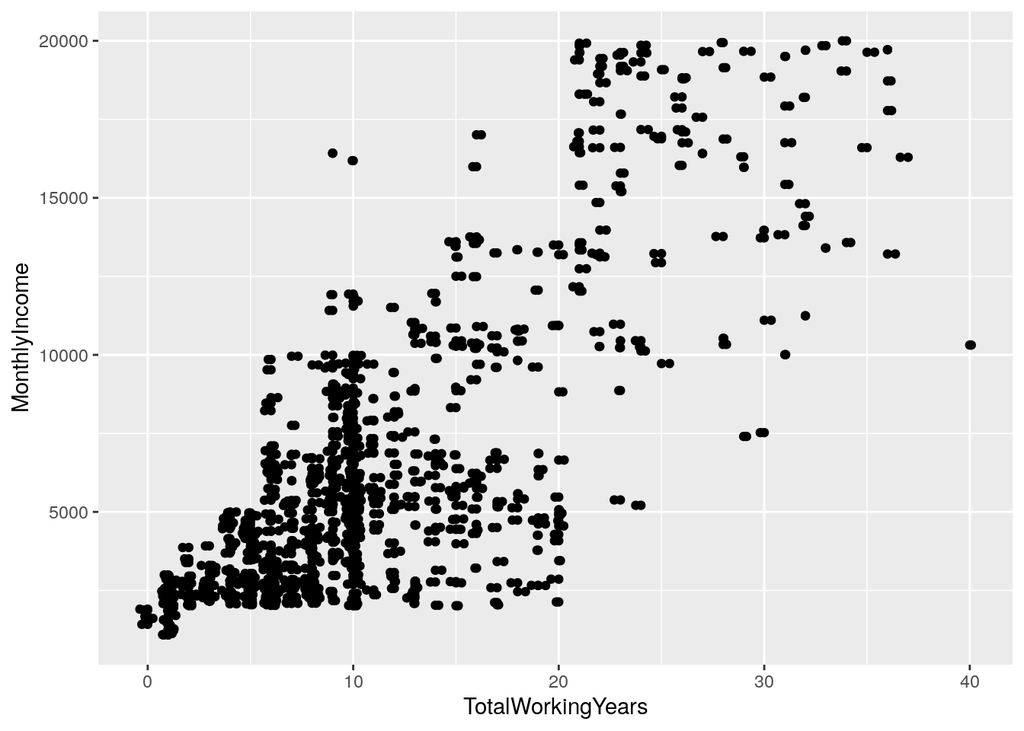

```r
case_study_2 %>% ggplot(aes(x = TotalWorkingYears, y = MonthlyIncome,)) + geom_point() + geom_jitter()
```

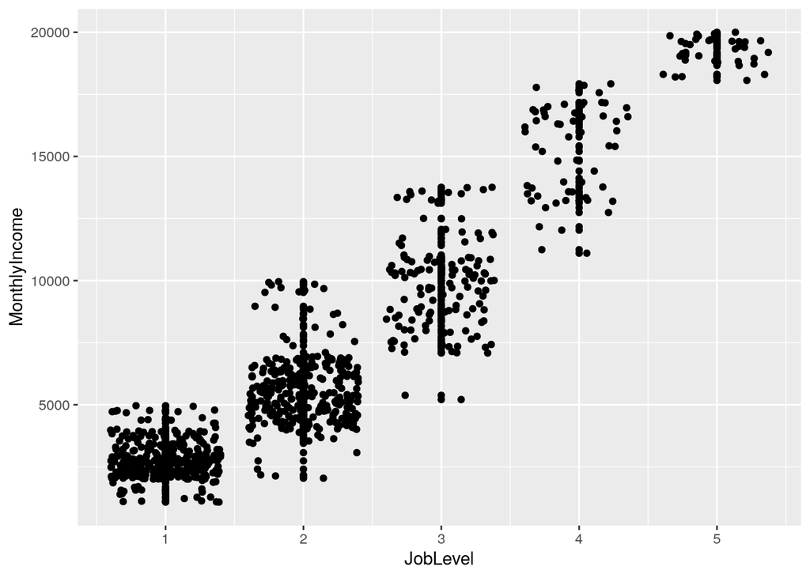

```r
case_study_2 %>% ggplot(aes(x = JobLevel, y = MonthlyIncome,)) + geom_point() + geom_jitter()
```

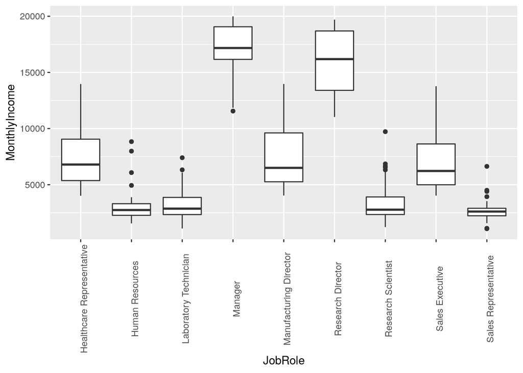

```r
case_study_2 %>% ggplot(aes(x = JobRole, y = MonthlyIncome,)) + geom_boxplot() + theme(axis.text.x = element_text(angle = 90))
```

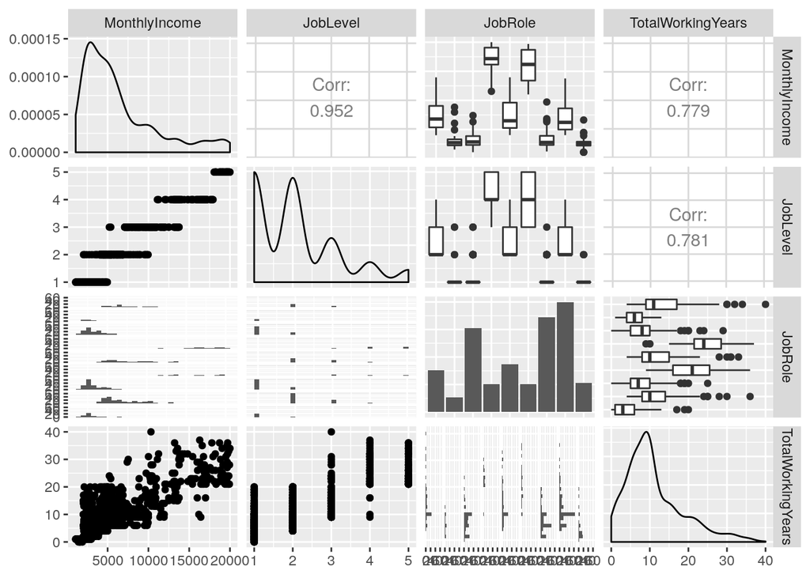

```r
ggpairs(case_study_2[,c(20,16,17,30)])
```

#Want to look at continous predictors as some levels look to be more like categorical rather than continous levels, and #still want to use as continous labels for NB and KNN classification

```r
all_variables = case_study_2 %>% names()


# remove the response
response_ind = match(c('ID','Age','Attrition','EmployeeCount','EmployeeNumber','HourlyRate','DailyRate','MonthlyIncome','MonthlyRate','Over18','PerformanceRating', 'StandardHours'), all_variables)

all_pred_variables = all_variables[-response_ind]


# plot categorical variables
for (i in all_pred_variables) {

print(i)
  CrossTable(case_study_2[, i], case_study_2[,"Attrition"],
             prop.r = T,
             prop.c = F,
             prop.t = F,
             prop.chisq = F,
             dnn = c(i, "Attrition"))

}
```

```
## [1] "BusinessTravel"
##
##
##    Cell Contents
## |-------------------------|
## |                       N |
## |           N / Row Total |
## |-------------------------|
##
##
## Total Observations in Table:  870
##
##
##                   | Attrition
##    BusinessTravel |        No |       Yes | Row Total |
## ------------------|-----------|-----------|-----------|
##        Non-Travel |        83 |        11 |        94 |
##                   |     0.883 |     0.117 |     0.108 |
## ------------------|-----------|-----------|-----------|
## Travel_Frequently |       123 |        35 |       158 |
##                   |     0.778 |     0.222 |     0.182 |
## ------------------|-----------|-----------|-----------|
##     Travel_Rarely |       524 |        94 |       618 |
##                   |     0.848 |     0.152 |     0.710 |
## ------------------|-----------|-----------|-----------|
##      Column Total |       730 |       140 |       870 |
## ------------------|-----------|-----------|-----------|
##
##
## [1] "Department"
##
##
##    Cell Contents
## |-------------------------|
## |                       N |
## |           N / Row Total |
## |-------------------------|
##
##
## Total Observations in Table:  870
```

[output cut: 1163 more lines]

```
##                      |     1.000 |     0.000 |     0.008 |
## ---------------------|-----------|-----------|-----------|
##                   14 |         3 |         1 |         4 |
##                      |     0.750 |     0.250 |     0.005 |
## ---------------------|-----------|-----------|-----------|
##                   15 |         1 |         0 |         1 |
##                      |     1.000 |     0.000 |     0.001 |
## ---------------------|-----------|-----------|-----------|
##                   17 |         4 |         0 |         4 |
##                      |     1.000 |     0.000 |     0.005 |
## ---------------------|-----------|-----------|-----------|
##         Column Total |       730 |       140 |       870 |
## ---------------------|-----------|-----------|-----------|
##
##
```

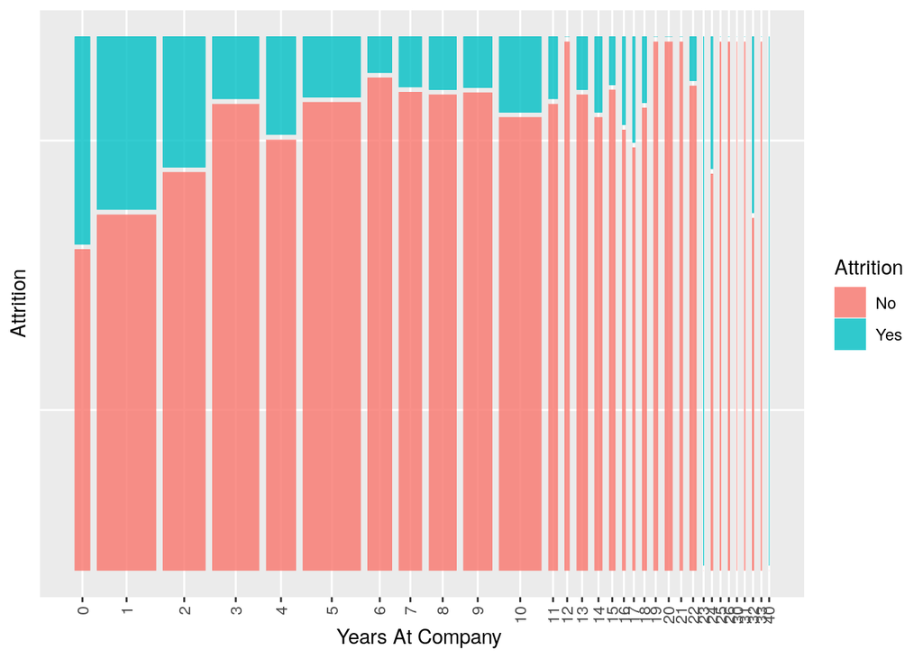

```r
case_study_2 %>%
  ggplot() +
  geom_mosaic(aes(x = product(Attrition, YearsAtCompany), fill = Attrition)) +
  theme(axis.text.x = element_text(angle = 90,
                                                hjust = 1,
                                                vjust = 0.5),
                     axis.text.y = element_blank(),
                     axis.ticks.y = element_blank()) +
  xlab("Years At Company ") +
   ylab("Attrition")
```

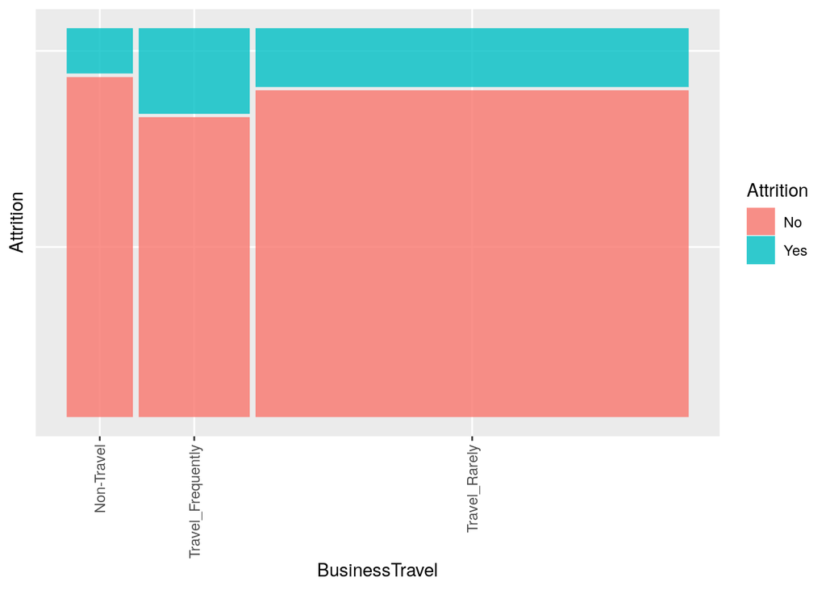

```r
case_study_2 %>%
  ggplot() +
  geom_mosaic(aes(x = product(Attrition,BusinessTravel), fill = Attrition)) +
  theme(axis.text.x = element_text(angle = 90,
                                                hjust = 1,
                                                vjust = 0.5),
                     axis.text.y = element_blank(),
                     axis.ticks.y = element_blank()) +
  xlab("BusinessTravel") +
   ylab("Attrition")
```

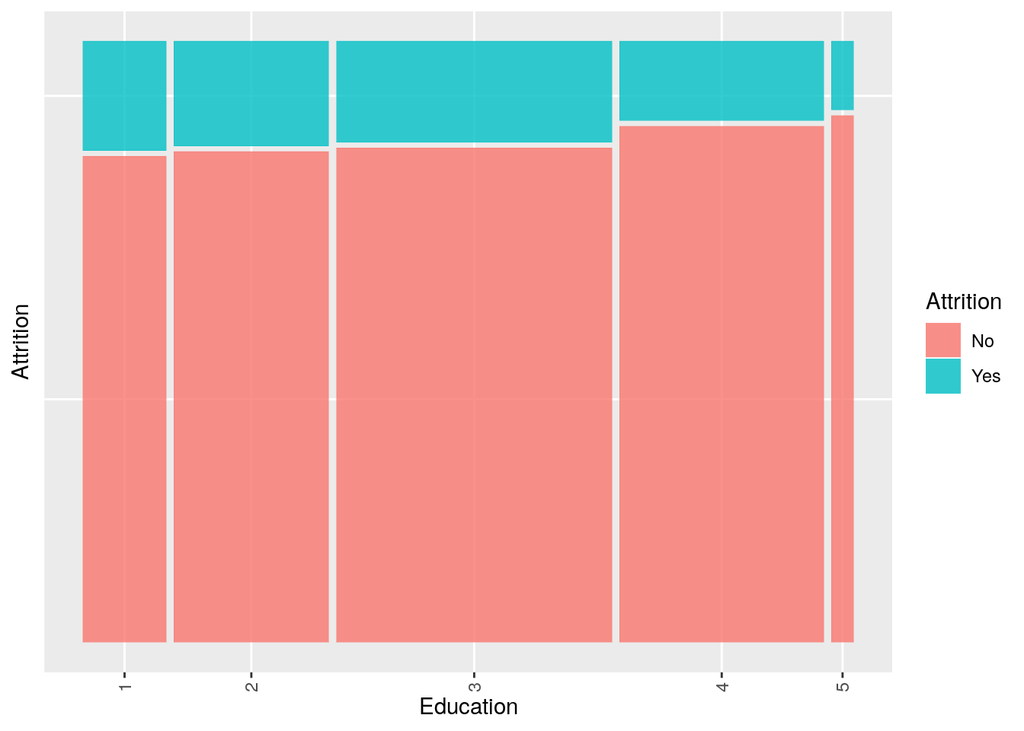

```r
case_study_2 %>%
  ggplot() +
  geom_mosaic(aes(x = product(Attrition,Education), fill = Attrition)) +
  theme(axis.text.x = element_text(angle = 90,
                                                hjust = 1,
                                                vjust = 0.5),
                     axis.text.y = element_blank(),
                     axis.ticks.y = element_blank()) +
  xlab("Education") +
   ylab("Attrition")
```

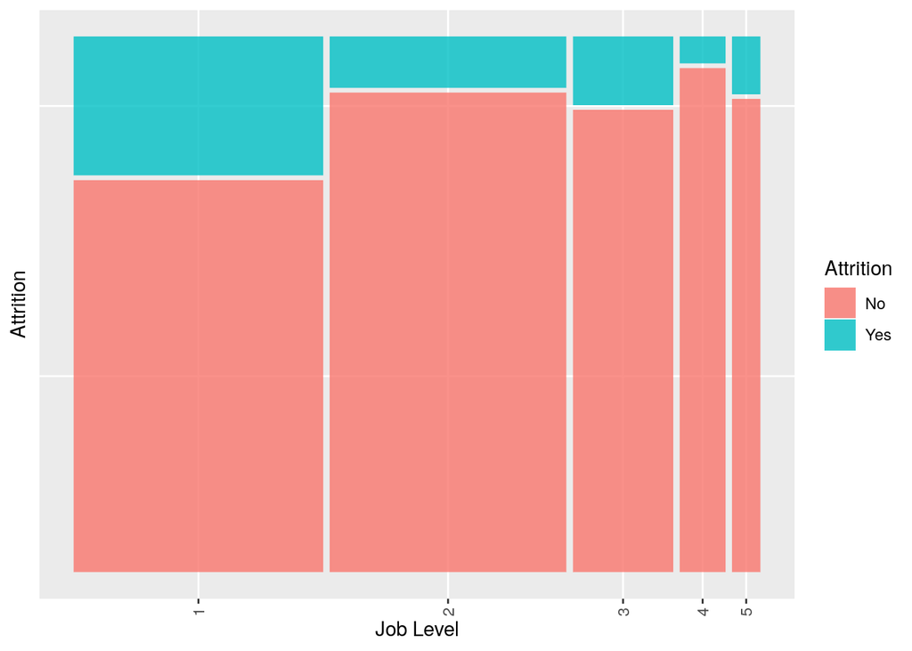

```r
case_study_2 %>%
  ggplot() +
  geom_mosaic(aes(x = product(Attrition,JobLevel), fill = Attrition)) +
  theme(axis.text.x = element_text(angle = 90,
                                                hjust = 1,
                                                vjust = 0.5),
                     axis.text.y = element_blank(),
                     axis.ticks.y = element_blank()) +
  xlab("Job Level") +
   ylab("Attrition")
```

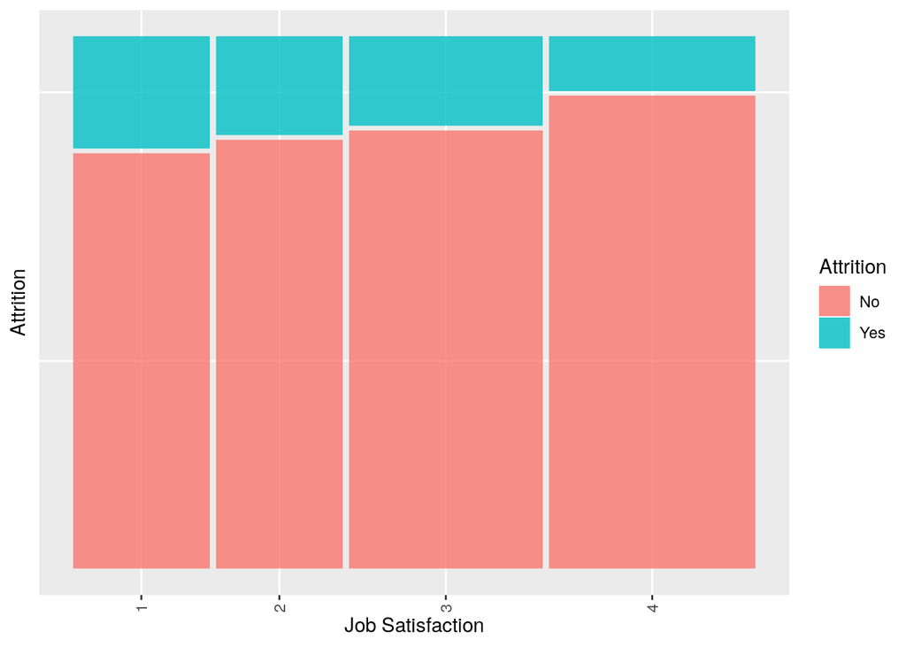

```r
case_study_2 %>%
  ggplot() +
  geom_mosaic(aes(x = product(Attrition,JobSatisfaction), fill = Attrition)) +
  theme(axis.text.x = element_text(angle = 90,
                                                hjust = 1,
                                                vjust = 0.5),
                     axis.text.y = element_blank(),
                     axis.ticks.y = element_blank()) +
  xlab("Job Satisfaction") +
   ylab("Attrition")
```

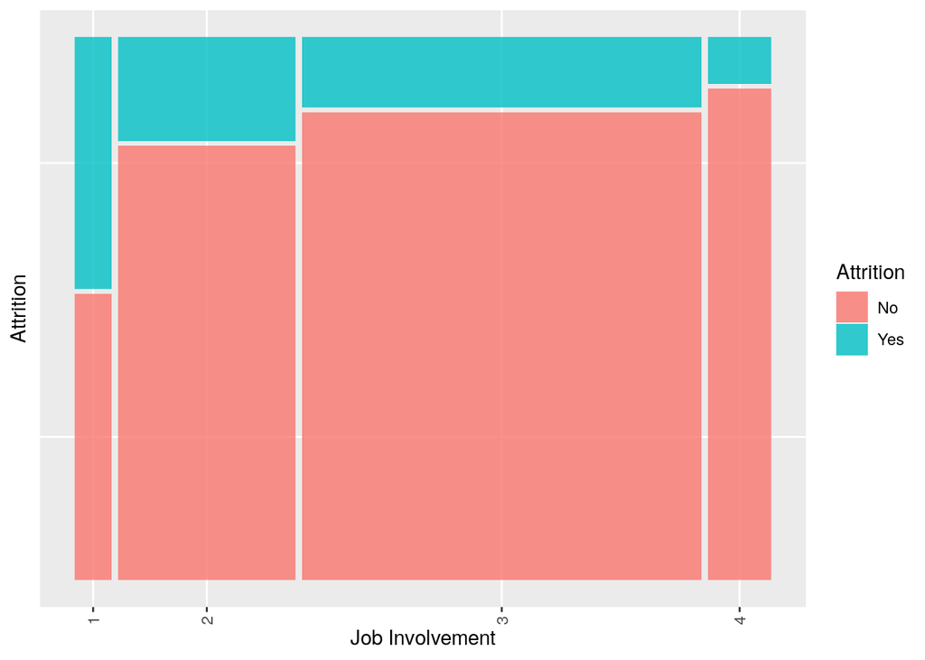

```r
case_study_2 %>%
  ggplot() +
  geom_mosaic(aes(x = product(Attrition,JobInvolvement), fill = Attrition)) +
  theme(axis.text.x = element_text(angle = 90,
                                                hjust = 1,
                                                vjust = 0.5),
                     axis.text.y = element_blank(),
                     axis.ticks.y = element_blank()) +
  xlab("Job Involvement") +
   ylab("Attrition")
```

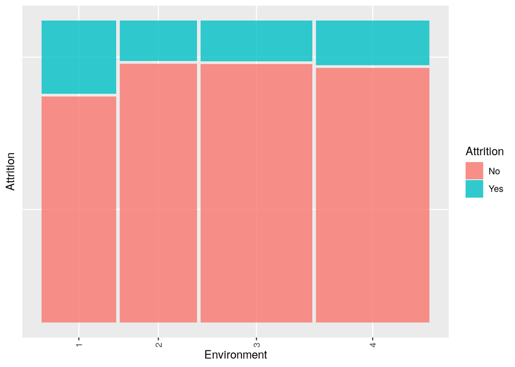

```r
case_study_2 %>%
  ggplot() +
  geom_mosaic(aes(x = product(Attrition,EnvironmentSatisfaction), fill = Attrition)) +
  theme(axis.text.x = element_text(angle = 90,
                                                hjust = 1,
                                                vjust = 0.5),
                     axis.text.y = element_blank(),
                     axis.ticks.y = element_blank()) +
  xlab("Environment") +
   ylab("Attrition")
```

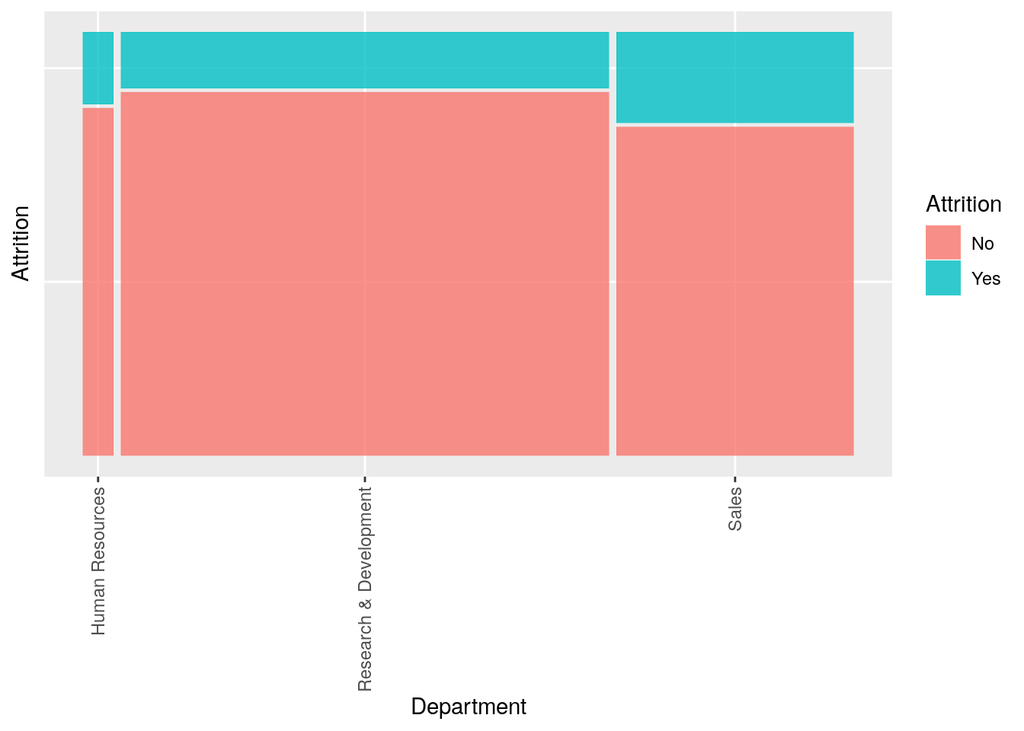

```r
case_study_2 %>%
  ggplot() +
  geom_mosaic(aes(x = product(Attrition,Department), fill = Attrition)) +
  theme(axis.text.x = element_text(angle = 90,
                                                hjust = 1,
                                                vjust = 0.5),
                     axis.text.y = element_blank(),
                     axis.ticks.y = element_blank()) +
  xlab("Department") +
   ylab("Attrition")
```

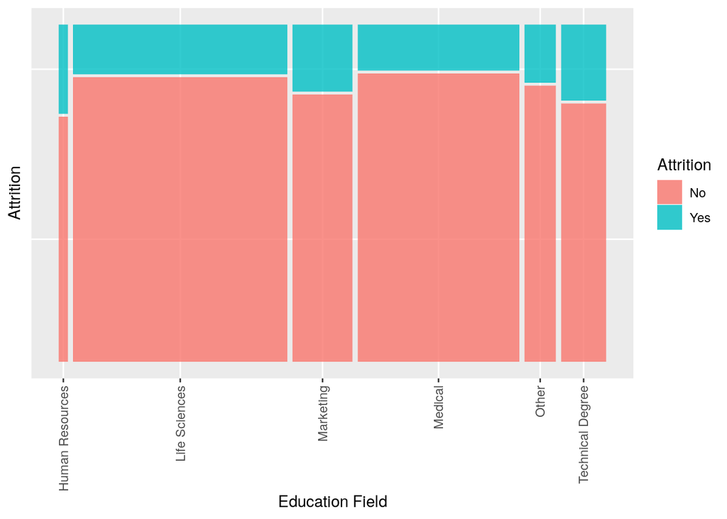

```r
case_study_2 %>%
  ggplot() +
  geom_mosaic(aes(x = product(Attrition,EducationField), fill = Attrition)) +
  theme(axis.text.x = element_text(angle = 90,
                                                hjust = 1,
                                                vjust = 0.5),
                     axis.text.y = element_blank(),
                     axis.ticks.y = element_blank()) +
  xlab("Education Field") +
   ylab("Attrition")
```

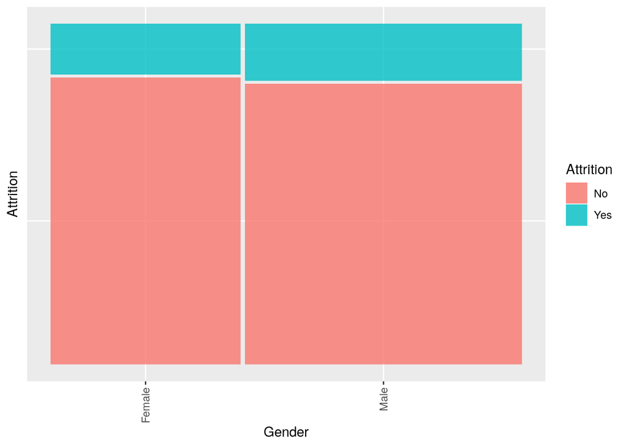

```r
case_study_2 %>%
  ggplot() +
  geom_mosaic(aes(x = product(Attrition,Gender), fill = Attrition)) +
  theme(axis.text.x = element_text(angle = 90,
                                                hjust = 1,
                                                vjust = 0.5),
                     axis.text.y = element_blank(),
                     axis.ticks.y = element_blank()) +
  xlab("Gender") +
   ylab("Attrition")
```

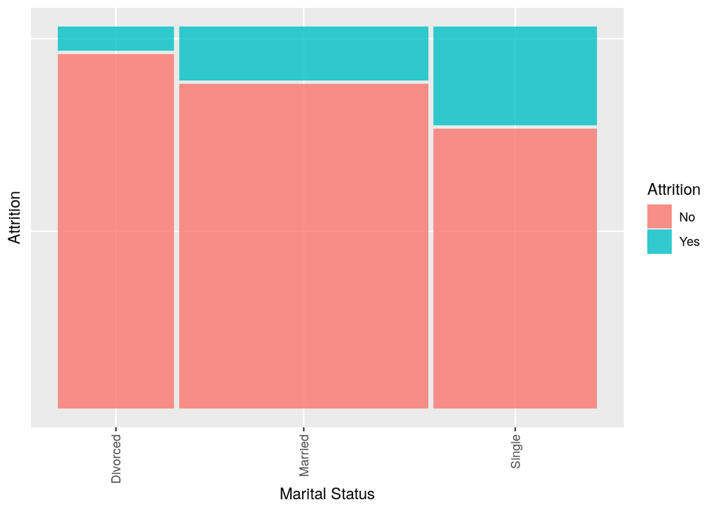

```r
case_study_2 %>%
  ggplot() +
  geom_mosaic(aes(x = product(Attrition,MaritalStatus), fill = Attrition)) +
  theme(axis.text.x = element_text(angle = 90,
                                                hjust = 1,
                                                vjust = 0.5),
                     axis.text.y = element_blank(),
                     axis.ticks.y = element_blank()) +
  xlab("Marital Status") +
   ylab("Attrition")
```

**We see from both the proportion tables and from the mosiac plots these factors lead to differences in attrition rates** **We also see these are chosen in forward selection methods for logistic regression.**

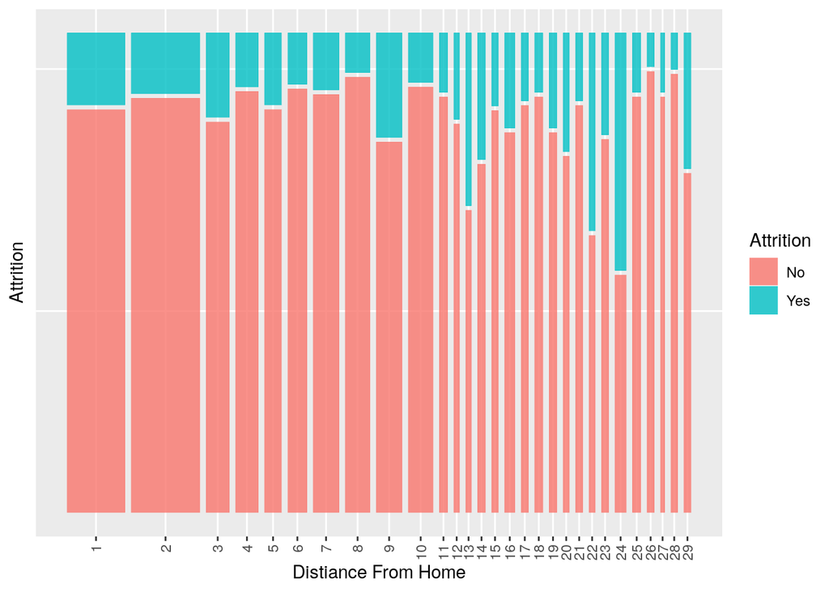

```r
case_study_2 %>%
  ggplot() +
  geom_mosaic(aes(x = product(Attrition,DistanceFromHome), fill = Attrition)) +
  theme(axis.text.x = element_text(angle = 90,
                                                hjust = 1,
                                                vjust = 0.5),
                     axis.text.y = element_blank(),
                     axis.ticks.y = element_blank()) +
  xlab("Distiance From Home") +
   ylab("Attrition")
```

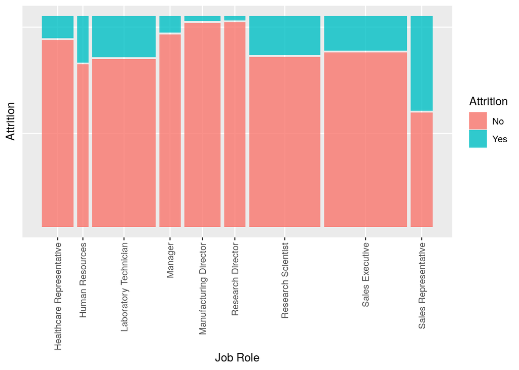

```r
  case_study_2 %>%
    ggplot() +
    geom_mosaic(aes(x = product(Attrition, JobRole), fill = Attrition)) +
    theme(axis.text.x = element_text(angle = 90,
                                                  hjust = 1,
                                                  vjust = 0.5),
                       axis.text.y = element_blank(),
                       axis.ticks.y = element_blank()) +
    xlab("Job Role") +
     ylab("Attrition")
```

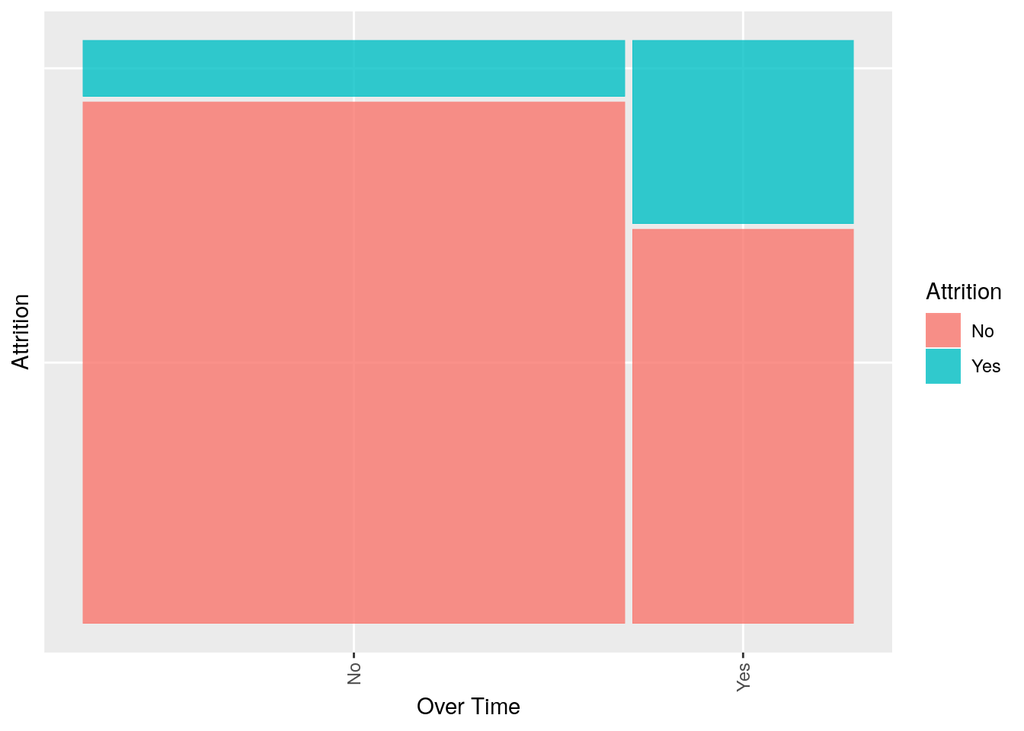

```r
case_study_2 %>%
  ggplot() +
  geom_mosaic(aes(x = product(Attrition, OverTime), fill = Attrition)) +
  theme(axis.text.x = element_text(angle = 90,
                                                hjust = 1,
                                                vjust = 0.5),
                     axis.text.y = element_blank(),
                     axis.ticks.y = element_blank()) +
  xlab("Over Time") +
   ylab("Attrition")
```

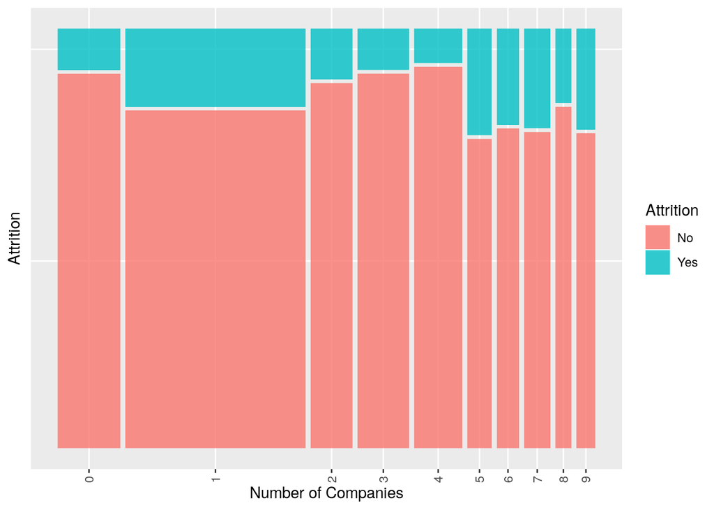

```r
case_study_2 %>%
  ggplot() +
  geom_mosaic(aes(x = product(Attrition, NumCompaniesWorked), fill = Attrition)) +
  theme(axis.text.x = element_text(angle = 90,
                                                hjust = 1,
                                                vjust = 0.5),
                     axis.text.y = element_blank(),
                     axis.ticks.y = element_blank()) +
  xlab("Number of Companies") +
   ylab("Attrition")
```

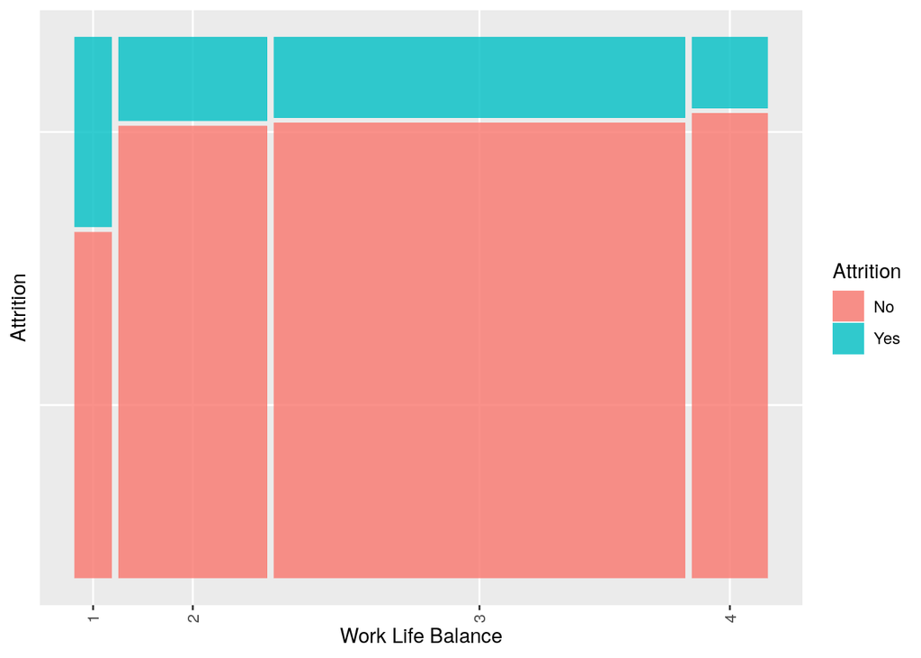

```r
case_study_2 %>%
  ggplot() +
  geom_mosaic(aes(x = product(Attrition, WorkLifeBalance), fill = Attrition)) +
  theme(axis.text.x = element_text(angle = 90,
                                                hjust = 1,
                                                vjust = 0.5),
                     axis.text.y = element_blank(),
                     axis.ticks.y = element_blank()) +
  xlab("Work Life Balance") +
   ylab("Attrition")
```

**TEST/TRAIN DATA SAMPLING**

```r
#creating a more balanced data set by upsampling.

set.seed(7474)
case_study_2_sample = upSample(case_study_2[,-c(3)], case_study_2[,3])

#Controling Sampling by modifying the p in the create partition for creating the test train splits from the downsampled data for training.
set.seed(7474)
case_study2_sample_idx = createDataPartition(case_study_2_sample$Class, p=.35, list = FALSE, times = 1)

case_study2_sample_train = case_study_2_sample[case_study2_sample_idx,]
case_study2_sample_test = case_study_2_sample[-case_study2_sample_idx,]



#Removing Row Number Partitions indices
row.names(case_study2_sample_train) = NULL
row.names(case_study2_sample_test) = NULL

case_study2_sample_train = case_study2_sample_train[,-c(1,22)]
case_study2_sample_test = case_study2_sample_test[,-c(1,22)]

#for regression
set.seed(7474)
case_study2_sample_idx_r = sample(dim(case_study_2)[1], .35*dim(case_study_2)[1])


case_study2_sample_train_r = case_study_2[case_study2_sample_idx_r,]
case_study2_sample_test_r = case_study_2[-case_study2_sample_idx_r,]

#Removing Row Number Partitions indices
row.names(case_study2_sample_train_r) = NULL
row.names(case_study2_sample_test_r) = NULL

case_study2_sample_train_r = case_study2_sample_train_r[,-c(1,23)]
case_study2_sample_test_r = case_study2_sample_test_r[,-c(1,23)]
```

**NB model**

```r
nb_model_1 = naiveBayes(case_study2_sample_train[,-c(34)], as.factor(case_study2_sample_train$Class))
table_cm = table(predict(nb_model_1, case_study2_sample_test[,-c(34)]), as.factor(case_study2_sample_test$Class))
CM = confusionMatrix(table_cm)
CM
```

```
## Confusion Matrix and Statistics
##
##
##        No Yes
##   No  294  90
##   Yes 180 384
##
##                Accuracy : 0.7152
##                  95% CI : (0.6853, 0.7437)
##     No Information Rate : 0.5
##     P-Value [Acc > NIR] : < 2.2e-16
##
##                   Kappa : 0.4304
##
##  Mcnemar's Test P-Value : 6.082e-08
##
##             Sensitivity : 0.6203
##             Specificity : 0.8101
##          Pos Pred Value : 0.7656
##          Neg Pred Value : 0.6809
##              Prevalence : 0.5000
##          Detection Rate : 0.3101
##    Detection Prevalence : 0.4051
##       Balanced Accuracy : 0.7152
##
##        'Positive' Class : No
##
```

**KNN model**

```r
colnames(case_study2_sample_test %>%  select_if(is.factor))
```

```
## [1] "BusinessTravel" "Department"     "EducationField" "Gender"
## [5] "JobRole"        "MaritalStatus"  "OverTime"       "Class"
```

```r
  knn_class = knn(case_study2_sample_train[,-c(2,4,7,11,15,17,21,34)],case_study2_sample_test[,-c(2,4,7,11,15,17,21,34)], case_study2_sample_train[,34], prob = TRUE, k = 2)
  class_table = table(case_study2_sample_test[,34], knn_class)
  confusemat = confusionMatrix(class_table)
  confusemat
```

```
## Confusion Matrix and Statistics
##
##      knn_class
##        No Yes
##   No  259 215
##   Yes  76 398
##
##                Accuracy : 0.693
##                  95% CI : (0.6626, 0.7223)
##     No Information Rate : 0.6466
##     P-Value [Acc > NIR] : 0.001422
##
##                   Kappa : 0.3861
##
##  Mcnemar's Test P-Value : 5.981e-16
##
##             Sensitivity : 0.7731
##             Specificity : 0.6493
##          Pos Pred Value : 0.5464
##          Neg Pred Value : 0.8397
##              Prevalence : 0.3534
##          Detection Rate : 0.2732
##    Detection Prevalence : 0.5000
##       Balanced Accuracy : 0.7112
##
##        'Positive' Class : No
##
```

**We see from the above EDA, Working Years, Job Role and Job Level are all stastically significant pvalue <0.05** **salary linear model**

```r
# need for confidence intervals

salary_model = lm(MonthlyIncome ~ TotalWorkingYears  + JobLevel + JobRole + MonthlyRate + Gender + EmployeeNumber,data = case_study2_sample_train_r)

salary_model_all = lm(MonthlyIncome ~ .,data = case_study2_sample_train_r)

step(salary_model,
     scope = list(upper=salary_model_all),
     direction="forward",
     test="Chisq",
     data=case_study2_sample_train_r)
```

```
## Start:  AIC=4225.24
## MonthlyIncome ~ TotalWorkingYears + JobLevel + JobRole + MonthlyRate +
##     Gender + EmployeeNumber
##
##                            Df Sum of Sq       RSS    AIC Pr(>Chi)
## + PerformanceRating         1   1987993 299347008 4225.2  0.15604
## <none>                                  301335000 4225.2
## + EducationField            5   9489586 291845415 4225.5  0.08334 .
## + RelationshipSatisfaction  1   1481253 299853748 4225.7  0.22097
## + StockOptionLevel          1   1394381 299940619 4225.8  0.23506
## + Department                1    886285 300448715 4226.3  0.34401
## + YearsSinceLastPromotion   1    620761 300714239 4226.6  0.42850
## + PercentSalaryHike         1    389602 300945398 4226.8  0.53057
## + JobInvolvement            1    296288 301038712 4226.9  0.58448
## + DistanceFromHome          1    184864 301150136 4227.1  0.66580
## + YearsAtCompany            1    112174 301222826 4227.1  0.73654
## + YearsWithCurrManager      1    101083 301233917 4227.1  0.74945
## + NumCompaniesWorked        1     94545 301240456 4227.1  0.75743
## + YearsInCurrentRole        1     89172 301245828 4227.1  0.76421
## + HourlyRate                1     78188 301256813 4227.2  0.77881
## + Education                 1     73807 301261193 4227.2  0.78494
## + DailyRate                 1     64886 301270114 4227.2  0.79805
## + EnvironmentSatisfaction   1     43802 301291199 4227.2  0.83350
## + Attrition                 1     37724 301297276 4227.2  0.84532
## + WorkLifeBalance           1     33701 301301299 4227.2  0.85370
## + Age                       1     16310 301318691 4227.2  0.89793
## + OverTime                  1      5607 301329393 4227.2  0.94005
## + TrainingTimesLastYear     1      3784 301331217 4227.2  0.95074
## + JobSatisfaction           1        61 301334939 4227.2  0.99373
## + BusinessTravel            2   1560677 299774323 4227.7  0.45417
## + MaritalStatus             2   1421679 299913321 4227.8  0.48733
## ---
## Signif. codes:  0 '***' 0.001 '**' 0.01 '*' 0.05 '.' 0.1 ' ' 1
##
## Step:  AIC=4225.23
## MonthlyIncome ~ TotalWorkingYears + JobLevel + JobRole + MonthlyRate +
##     Gender + EmployeeNumber + PerformanceRating
##
##                            Df Sum of Sq       RSS    AIC Pr(>Chi)
## <none>                                  299347008 4225.2
```

[output cut: 11 more lines]

```
## + DailyRate                 1     78292 299268715 4227.1  0.77795
## + YearsInCurrentRole        1     71504 299275503 4227.2  0.78755
## + EnvironmentSatisfaction   1     69203 299277805 4227.2  0.79092
## + YearsAtCompany            1     62227 299284780 4227.2  0.80151
## + WorkLifeBalance           1     40018 299306989 4227.2  0.84023
## + HourlyRate                1     34524 299312483 4227.2  0.85146
## + Attrition                 1     20613 299326395 4227.2  0.88496
## + TrainingTimesLastYear     1     10899 299336109 4227.2  0.91621
## + OverTime                  1      8654 299338353 4227.2  0.92531
## + Age                       1      2741 299344267 4227.2  0.95792
## + JobSatisfaction           1       318 299346689 4227.2  0.98565
## + BusinessTravel            2   1551977 297795030 4227.6  0.45380
## + MaritalStatus             2   1231043 298115965 4228.0  0.53452
## ---
## Signif. codes:  0 '***' 0.001 '**' 0.01 '*' 0.05 '.' 0.1 ' ' 1
```

```
##
## Call:
## lm(formula = MonthlyIncome ~ TotalWorkingYears + JobLevel + JobRole +
##     MonthlyRate + Gender + EmployeeNumber + PerformanceRating,
##     data = case_study2_sample_train_r)
##
## Coefficients:
##                   (Intercept)              TotalWorkingYears
##                     456.32865                       59.45786
##                      JobLevel         JobRoleHuman Resources
##                    2760.44296                     -585.48286
##  JobRoleLaboratory Technician                 JobRoleManager
##                    -549.70822                     3941.79927
## JobRoleManufacturing Director       JobRoleResearch Director
##                     280.52167                     3618.71036
##     JobRoleResearch Scientist         JobRoleSales Executive
##                    -278.77541                      -17.30555
##   JobRoleSales Representative                    MonthlyRate
##                    -317.70256                       -0.01944
##                    GenderMale                 EmployeeNumber
##                     263.92014                        0.20903
##             PerformanceRating
##                    -217.86178
```

```r
#salary_model = lm(MonthlyIncome ~ TotalWorkingYears  , data = case_study2_sample_train)

summary(salary_model)
```

```
##
## Call:
## lm(formula = MonthlyIncome ~ TotalWorkingYears + JobLevel + JobRole +
##     MonthlyRate + Gender + EmployeeNumber, data = case_study2_sample_train_r)
##
## Residuals:
##     Min      1Q  Median      3Q     Max
## -3402.2  -573.7   -47.9   652.5  3196.4
##
## Coefficients:
##                                 Estimate Std. Error t value Pr(>|t|)
## (Intercept)                   -2.719e+02  3.643e+02  -0.746   0.4562
## TotalWorkingYears              6.099e+01  1.304e+01   4.678 4.45e-06 ***
## JobLevel                       2.753e+03  1.339e+02  20.563  < 2e-16 ***
## JobRoleHuman Resources        -5.582e+02  3.878e+02  -1.439   0.1511
## JobRoleLaboratory Technician  -5.186e+02  2.788e+02  -1.860   0.0638 .
## JobRoleManager                 3.955e+03  3.646e+02  10.849  < 2e-16 ***
## JobRoleManufacturing Director  2.997e+02  2.852e+02   1.051   0.2941
## JobRoleResearch Director       3.668e+03  3.403e+02  10.779  < 2e-16 ***
## JobRoleResearch Scientist     -2.618e+02  2.837e+02  -0.923   0.3569
## JobRoleSales Executive         1.019e+01  2.374e+02   0.043   0.9658
## JobRoleSales Representative   -2.809e+02  3.454e+02  -0.813   0.4167
## MonthlyRate                   -1.891e-02  8.386e-03  -2.255   0.0249 *
## GenderMale                     2.628e+02  1.196e+02   2.197   0.0288 *
## EmployeeNumber                 2.129e-01  1.030e-01   2.067   0.0397 *
## ---
## Signif. codes:  0 '***' 0.001 '**' 0.01 '*' 0.05 '.' 0.1 ' ' 1
##
## Residual standard error: 1019 on 290 degrees of freedom
## Multiple R-squared:  0.9547, Adjusted R-squared:  0.9527
## F-statistic: 470.5 on 13 and 290 DF,  p-value: < 2.2e-16
```

```r
confint(salary_model)
```

```
##                                       2.5 %        97.5 %
## (Intercept)                   -9.889341e+02  4.452286e+02
## TotalWorkingYears              3.532994e+01  8.665687e+01
## JobLevel                       2.489568e+03  3.016585e+03
## JobRoleHuman Resources        -1.321457e+03  2.050846e+02
## JobRoleLaboratory Technician  -1.067303e+03  3.005098e+01
## JobRoleManager                 3.237706e+03  4.672805e+03
## JobRoleManufacturing Director -2.615316e+02  8.610244e+02
## JobRoleResearch Director       2.998105e+03  4.337625e+03
## JobRoleResearch Scientist     -8.202221e+02  2.966300e+02
## JobRoleSales Executive        -4.571112e+02  4.774921e+02
## JobRoleSales Representative   -9.607156e+02  3.988678e+02
## MonthlyRate                   -3.541519e-02 -2.403929e-03
## GenderMale                     2.740956e+01  4.981899e+02
## EmployeeNumber                 1.013602e-02  4.156338e-01
```

```r
vif(salary_model)
```

```
##                       GVIF Df GVIF^(1/(2*Df))
## TotalWorkingYears 2.811645  1        1.676796
## JobLevel          6.468078  1        2.543242
## JobRole           4.978251  8        1.105522
## MonthlyRate       1.059364  1        1.029254
## Gender            1.020106  1        1.010003
## EmployeeNumber    1.041268  1        1.020425
```

```r
#preditive final model

final_model = train(MonthlyIncome ~  TotalWorkingYears + JobLevel + JobRole + MonthlyRate + Gender + EmployeeNumber, method = "lm", data = case_study2_sample_train_r, trControl = trainControl(method = "LOOCV"))



final_model
```

```
## Linear Regression
##
## 304 samples
##   6 predictor
##
## No pre-processing
## Resampling: Leave-One-Out Cross-Validation
## Summary of sample sizes: 303, 303, 303, 303, 303, 303, ...
## Resampling results:
##
##   RMSE      Rsquared   MAE
##   1044.334  0.9501975  810.7875
##
## Tuning parameter 'intercept' was held constant at a value of TRUE
```

```r
summary(final_model)
```

```
##
## Call:
## lm(formula = .outcome ~ ., data = dat)
##
## Residuals:
##     Min      1Q  Median      3Q     Max
## -3402.2  -573.7   -47.9   652.5  3196.4
##
## Coefficients:
##                                   Estimate Std. Error t value Pr(>|t|)
## (Intercept)                     -2.719e+02  3.643e+02  -0.746   0.4562
## TotalWorkingYears                6.099e+01  1.304e+01   4.678 4.45e-06 ***
## JobLevel                         2.753e+03  1.339e+02  20.563  < 2e-16 ***
## `JobRoleHuman Resources`        -5.582e+02  3.878e+02  -1.439   0.1511
## `JobRoleLaboratory Technician`  -5.186e+02  2.788e+02  -1.860   0.0638 .
## JobRoleManager                   3.955e+03  3.646e+02  10.849  < 2e-16 ***
## `JobRoleManufacturing Director`  2.997e+02  2.852e+02   1.051   0.2941
## `JobRoleResearch Director`       3.668e+03  3.403e+02  10.779  < 2e-16 ***
## `JobRoleResearch Scientist`     -2.618e+02  2.837e+02  -0.923   0.3569
## `JobRoleSales Executive`         1.019e+01  2.374e+02   0.043   0.9658
## `JobRoleSales Representative`   -2.809e+02  3.454e+02  -0.813   0.4167
## MonthlyRate                     -1.891e-02  8.386e-03  -2.255   0.0249 *
## GenderMale                       2.628e+02  1.196e+02   2.197   0.0288 *
## EmployeeNumber                   2.129e-01  1.030e-01   2.067   0.0397 *
## ---
## Signif. codes:  0 '***' 0.001 '**' 0.01 '*' 0.05 '.' 0.1 ' ' 1
##
## Residual standard error: 1019 on 290 degrees of freedom
## Multiple R-squared:  0.9547, Adjusted R-squared:  0.9527
## F-statistic: 470.5 on 13 and 290 DF,  p-value: < 2.2e-16
```

```r
salary_pred = predict(final_model, newdata = case_study2_sample_test_r, interval = "prediction")

salary_pred
```

```
##         1         2         3         4         5         6         7         8
##  6003.193 18613.441  2610.212  9163.972  3112.283  5509.630  2137.762  6035.103
##         9        10        11        12        13        14        15        16
## 18700.688  2565.921  9409.894  2302.569  2378.596  5971.341  5761.291  3116.172
##        17        18        19        20        21        22        23        24
##  6335.085  6039.124  5358.413  6052.124 19401.662  6220.381  9483.737  2452.800
##        25        26        27        28        29        30        31        32
##  5666.379  3182.914 16197.593  2775.850  2113.969  6688.396 20116.134 17176.646
##        33        34        35        36        37        38        39        40
##  2884.232  2493.994  2698.375  6256.673  2441.419  2781.707 18991.486  2716.766
##        41        42        43        44        45        46        47        48
##  2519.572  2866.386  2643.063  8767.943  2950.109  6053.055  2693.771  2694.967
##        49        50        51        52        53        54        55        56
##  5741.793  6047.315  8964.719  9146.270  2112.228  6561.808  5807.644  6863.474
##        57        58        59        60        61        62        63        64
## 12676.923  6658.533  2554.883  8764.973 18367.176  2175.836  8705.437  2607.896
##        65        66        67        68        69        70        71        72
##  6102.228 18455.295  6345.656  6263.862  2440.396  2627.479  2751.428  5480.882
##        73        74        75        76        77        78        79        80
##  2775.715 16745.526  5954.061 19778.302  6209.861  2493.203 16490.613  9296.331
##        81        82        83        84        85        86        87        88
##  6284.301  8971.719  5686.263  5577.701  3236.313  2533.530  9178.380  5736.049
##        89        90        91        92        93        94        95        96
##  5816.716  6015.200  2747.871  6094.196  6112.589  5951.589  6430.441  5242.238
##        97        98        99       100       101       102       103       104
##  5706.255  2070.819  9580.975 13263.257  2389.582  9099.450  5583.104  5531.006
##       105       106       107       108       109       110       111       112
##  2719.881  5858.417  5860.533  6260.535  2354.825  5474.823 12267.868  9406.591
##       113       114       115       116       117       118       119       120
## 12699.280  5308.033  8856.825  5631.033  5221.087  8982.281 16341.319 14721.598
##       121       122       123       124       125       126       127       128
##  6049.647  2618.833  6582.735  2103.284  2782.170  8295.794  5780.875  9346.054
##       129       130       131       132       133       134       135       136
##  3049.458  2240.750  2818.042  6481.662 16422.586  5672.124  5511.647  3010.140
##       137       138       139       140       141       142       143       144
##  2505.945 12372.935  2251.199 11979.598  5726.765  2913.892  2239.601  3022.566
##       145       146       147       148       149       150       151       152
##  5744.919  6379.322  8628.949  6121.447  2649.280  3131.840  6047.850  2113.567
##       153       154       155       156       157       158       159       160
##  2626.889  3234.884  2552.333  2149.541  5963.219 16148.357  9221.585 19280.434
```

[output cut: 87 more lines]

```
##  9396.101  6460.540  6057.380  2211.580  9691.426  2399.921  2579.176  2231.985
##       513       514       515       516       517       518       519       520
##  2787.269  2663.726  2086.202  6210.974  6021.393  6052.904 15094.392  5662.823
##       521       522       523       524       525       526       527       528
##  2262.737  5210.608  2712.959  8977.266  8886.838 12221.467  5805.117  5569.911
##       529       530       531       532       533       534       535       536
##  9055.458  5553.042 19342.838  2607.343  3541.342  6060.685  5580.382  5995.889
##       537       538       539       540       541       542       543       544
##  6069.721 18649.102  5646.975  2584.363 19649.215  5475.254  2614.821 12865.163
##       545       546       547       548       549       550       551       552
##  8476.151  3168.947 19333.611  8419.281 12755.756  9042.339  5446.573  1761.899
##       553       554       555       556       557       558       559       560
##  5984.440  2987.362  5056.989  5088.991  5699.445  2535.534  8725.776  2563.299
##       561       562       563       564       565       566
##  2646.159 12423.921  9193.385  9157.290  5593.935  2520.697
```

[figure not shown]

```r
RSME = sqrt(mean((salary_pred-case_study2_sample_test_r$MonthlyIncome)^2))

salary_pred_submit = predict(final_model, newdata = case_study_salary_preds , interval = "prediction")

case_study_salary_preds["MonthlyIncome"] = salary_pred_submit


par(mfrow=c(1,2))
plot(salary_model$fitted.values,salary_model$residuals,ylab="Resdiduals",xlab="Fitted")
qqnorm(salary_model$residuals)
```

```r
case_study_salary_preds_out = case_study_salary_preds[,c("ID", "MonthlyIncome")]

head(case_study_salary_preds_out, n= 5)
```

```
##    ID MonthlyIncome
## 1 871      5963.935
## 2 872      2410.196
## 3 873     12593.940
## 4 874      2770.591
## 5 875      2688.975
```

#Looking at logistic regression

```r
#Starting with a base logistic regression model for using as a forward selection criteria later

main.logr = glm(Class ~ .,data=case_study2_sample_train ,family=binomial(link='logit'))

#Looking at some highly influential factors for predicting attrition from EDA analysis above

main.logr_l_3 = glm(Class ~ Age + DailyRate + Department + Education + EducationField + JobLevel + JobSatisfaction + MaritalStatus + YearsInCurrentRole,data=case_study2_sample_train ,family=binomial(link='logit'))


#Performing step forward selection and looking at AIC of models for best fit criteria to data
step(main.logr_l_3,
     scope = list(upper=main.logr),
     direction="forward",
     test="Chisq",
     data=case_study2_sample_train)
```

```
## Start:  AIC=618.59
## Class ~ Age + DailyRate + Department + Education + EducationField +
##     JobLevel + JobSatisfaction + MaritalStatus + YearsInCurrentRole
##
##                            Df Deviance    AIC    LRT  Pr(>Chi)
## + OverTime                  1   503.72 537.72 82.866 < 2.2e-16 ***
## + JobInvolvement            1   569.43 603.43 17.162 3.432e-05 ***
## + TrainingTimesLastYear     1   570.74 604.74 15.853 6.847e-05 ***
## + YearsSinceLastPromotion   1   570.78 604.78 15.805 7.021e-05 ***
## + BusinessTravel            2   571.50 607.50 15.088 0.0005292 ***
## + NumCompaniesWorked        1   573.91 607.91 12.678 0.0003699 ***
## + WorkLifeBalance           1   577.01 611.01  9.584 0.0019625 **
## + YearsWithCurrManager      1   582.10 616.10  4.486 0.0341763 *
## + EnvironmentSatisfaction   1   582.17 616.17  4.419 0.0355353 *
## + DistanceFromHome          1   582.61 616.61  3.979 0.0460735 *
## + RelationshipSatisfaction  1   583.81 617.81  2.778 0.0955918 .
## + MonthlyIncome             1   584.05 618.05  2.541 0.1108904
## + HourlyRate                1   584.18 618.18  2.405 0.1209757
## <none>                          586.59 618.59
## + MonthlyRate               1   585.15 619.15  1.438 0.2304805
## + Gender                    1   585.50 619.50  1.086 0.2974134
## + StockOptionLevel          1   585.79 619.79  0.804 0.3697644
## + YearsAtCompany            1   586.00 620.00  0.591 0.4419524
## + PerformanceRating         1   586.37 620.37  0.218 0.6408549
## + TotalWorkingYears         1   586.46 620.46  0.125 0.7231572
## + PercentSalaryHike         1   586.52 620.52  0.067 0.7951220
## + EmployeeNumber            1   586.56 620.56  0.028 0.8660415
## + JobRole                   8   575.96 623.96 10.630 0.2235881
## ---
## Signif. codes:  0 '***' 0.001 '**' 0.01 '*' 0.05 '.' 0.1 ' ' 1
##
## Step:  AIC=537.72
## Class ~ Age + DailyRate + Department + Education + EducationField +
##     JobLevel + JobSatisfaction + MaritalStatus + YearsInCurrentRole +
##     OverTime
##
##                            Df Deviance    AIC     LRT  Pr(>Chi)
## + JobInvolvement            1   488.94 524.94 14.7808 0.0001208 ***
## + TrainingTimesLastYear     1   489.30 525.30 14.4234 0.0001460 ***
## + YearsSinceLastPromotion   1   490.19 526.19 13.5301 0.0002348 ***
```

[output cut: 390 more lines]

```
## Class ~ Age + DailyRate + Department + Education + EducationField +
##     JobLevel + JobSatisfaction + MaritalStatus + YearsInCurrentRole +
##     OverTime + JobInvolvement + YearsSinceLastPromotion + TrainingTimesLastYear +
##     NumCompaniesWorked + WorkLifeBalance + BusinessTravel + EnvironmentSatisfaction +
##     YearsWithCurrManager + JobRole + DistanceFromHome + StockOptionLevel +
##     YearsAtCompany + TotalWorkingYears + Gender + RelationshipSatisfaction +
##     MonthlyRate
##
##                     Df Deviance    AIC     LRT Pr(>Chi)
## <none>                   355.87 437.87
## + HourlyRate         1   354.79 438.79 1.08075   0.2985
## + EmployeeNumber     1   355.30 439.30 0.57534   0.4481
## + PerformanceRating  1   355.44 439.44 0.43486   0.5096
## + MonthlyIncome      1   355.50 439.50 0.37505   0.5403
## + PercentSalaryHike  1   355.84 439.84 0.03697   0.8475
```

```
##
## Call:  glm(formula = Class ~ Age + DailyRate + Department + Education +
##     EducationField + JobLevel + JobSatisfaction + MaritalStatus +
##     YearsInCurrentRole + OverTime + JobInvolvement + YearsSinceLastPromotion +
##     TrainingTimesLastYear + NumCompaniesWorked + WorkLifeBalance +
##     BusinessTravel + EnvironmentSatisfaction + YearsWithCurrManager +
##     JobRole + DistanceFromHome + StockOptionLevel + YearsAtCompany +
##     TotalWorkingYears + Gender + RelationshipSatisfaction + MonthlyRate,
##     family = binomial(link = "logit"), data = case_study2_sample_train)
##
## Coefficients:
##                      (Intercept)                               Age
##                       -6.860e+00                        -3.549e-02
##                        DailyRate  DepartmentResearch & Development
##                       -8.469e-04                         1.445e+01
##                  DepartmentSales                         Education
##                        1.534e+01                         4.008e-02
##      EducationFieldLife Sciences           EducationFieldMarketing
##                       -3.995e+00                        -4.799e+00
##            EducationFieldMedical               EducationFieldOther
##                       -4.064e+00                        -3.732e+00
##   EducationFieldTechnical Degree                          JobLevel
##                       -2.762e+00                         8.483e-01
##                  JobSatisfaction              MaritalStatusMarried
##                       -6.902e-01                         9.573e-01
##              MaritalStatusSingle                YearsInCurrentRole
##                        1.991e+00                        -3.091e-01
##                      OverTimeYes                    JobInvolvement
##                        2.726e+00                        -6.579e-01
##          YearsSinceLastPromotion             TrainingTimesLastYear
##                        3.006e-01                        -5.633e-01
##               NumCompaniesWorked                   WorkLifeBalance
##                        3.058e-01                        -6.881e-01
##  BusinessTravelTravel_Frequently       BusinessTravelTravel_Rarely
##                        1.783e+00                         1.735e+00
##          EnvironmentSatisfaction              YearsWithCurrManager
##                       -3.561e-01                        -2.162e-01
##           JobRoleHuman Resources      JobRoleLaboratory Technician
##                        1.591e+01                         2.732e+00
##                   JobRoleManager     JobRoleManufacturing Director
##                       -1.755e-02                        -5.883e-01
##         JobRoleResearch Director         JobRoleResearch Scientist
##                       -3.456e-01                         1.706e+00
##           JobRoleSales Executive       JobRoleSales Representative
##                        1.385e+00                         3.607e+00
##                 DistanceFromHome                  StockOptionLevel
##                        5.497e-02                         3.776e-01
##                   YearsAtCompany                 TotalWorkingYears
##                        1.456e-01                        -1.235e-01
##                       GenderMale          RelationshipSatisfaction
##                       -6.165e-01                        -2.855e-01
##                      MonthlyRate
##                       -3.374e-05
##
## Degrees of Freedom: 511 Total (i.e. Null);  471 Residual
## Null Deviance:       709.8
## Residual Deviance: 355.9     AIC: 437.9
```

```r
#looking at model AIC
main.logr_l_3$aic
```

```
## [1] 618.5896
```

```r
#looking at model attributes
summary(main.logr_l_3)
```

```
##
## Call:
## glm(formula = Class ~ Age + DailyRate + Department + Education +
##     EducationField + JobLevel + JobSatisfaction + MaritalStatus +
##     YearsInCurrentRole, family = binomial(link = "logit"), data = case_study2_sample_train)
##
## Deviance Residuals:
##      Min        1Q    Median        3Q       Max
## -2.36413  -0.95383  -0.00607   0.92870   2.27652
##
## Coefficients:
##                                    Estimate Std. Error z value Pr(>|z|)
## (Intercept)                       3.0439619  0.8750706   3.479 0.000504 ***
## Age                              -0.0295900  0.0128554  -2.302 0.021349 *
## DailyRate                        -0.0004315  0.0002551  -1.692 0.090721 .
## DepartmentResearch & Development  0.8465374  0.7152521   1.184 0.236591
## DepartmentSales                   1.7554674  0.7366670   2.383 0.017173 *
## Education                        -0.0396096  0.1074778  -0.369 0.712472
## EducationFieldLife Sciences      -1.7000098  0.9809781  -1.733 0.083100 .
## EducationFieldMarketing          -2.1262600  1.0225673  -2.079 0.037587 *
## EducationFieldMedical            -1.8407421  0.9861251  -1.867 0.061952 .
## EducationFieldOther              -1.7489242  1.0405505  -1.681 0.092808 .
## EducationFieldTechnical Degree   -1.0192105  1.0059631  -1.013 0.310979
## JobLevel                         -0.1614222  0.1154607  -1.398 0.162092
## JobSatisfaction                  -0.4779966  0.0927760  -5.152 2.58e-07 ***
## MaritalStatusMarried              0.8759221  0.2939477   2.980 0.002884 **
## MaritalStatusSingle               1.4375099  0.3012088   4.772 1.82e-06 ***
## YearsInCurrentRole               -0.1104721  0.0334632  -3.301 0.000962 ***
## ---
## Signif. codes:  0 '***' 0.001 '**' 0.01 '*' 0.05 '.' 0.1 ' ' 1
##
## (Dispersion parameter for binomial family taken to be 1)
##
##     Null deviance: 709.78  on 511  degrees of freedom
## Residual deviance: 586.59  on 496  degrees of freedom
## AIC: 618.59
##
## Number of Fisher Scoring iterations: 4
```

```r
#Looking at model coeffiecients
coefficients(main.logr_l_3)
```

```
##                      (Intercept)                              Age
##                     3.0439619369                    -0.0295899862
##                        DailyRate DepartmentResearch & Development
##                    -0.0004315007                     0.8465373808
##                  DepartmentSales                        Education
##                     1.7554673938                    -0.0396096008
##      EducationFieldLife Sciences          EducationFieldMarketing
##                    -1.7000098395                    -2.1262600488
##            EducationFieldMedical              EducationFieldOther
##                    -1.8407420970                    -1.7489242280
##   EducationFieldTechnical Degree                         JobLevel
##                    -1.0192105284                    -0.1614222039
##                  JobSatisfaction             MaritalStatusMarried
##                    -0.4779966185                     0.8759221282
##              MaritalStatusSingle               YearsInCurrentRole
##                     1.4375099284                    -0.1104720769
```

```r
#looking at model fit for data
hoslem.test(main.logr_l_3$y, fitted(main.logr_l_3), g=10)
```

```
##
##  Hosmer and Lemeshow goodness of fit (GOF) test
##
## data:  main.logr_l_3$y, fitted(main.logr_l_3)
## X-squared = 12.906, df = 8, p-value = 0.1151
```

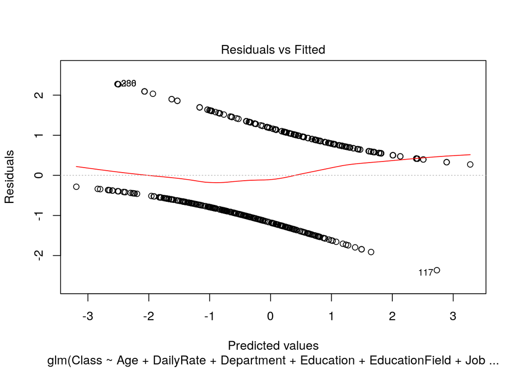

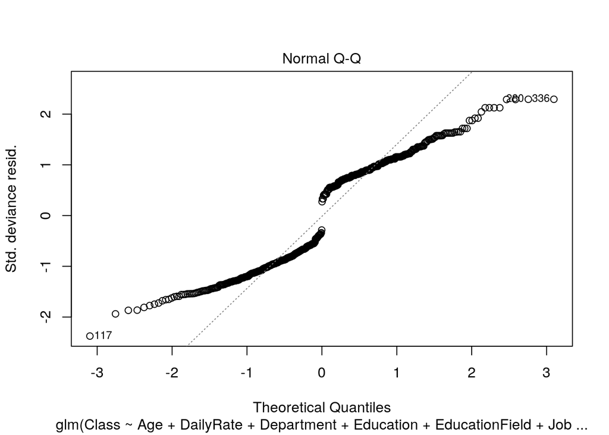

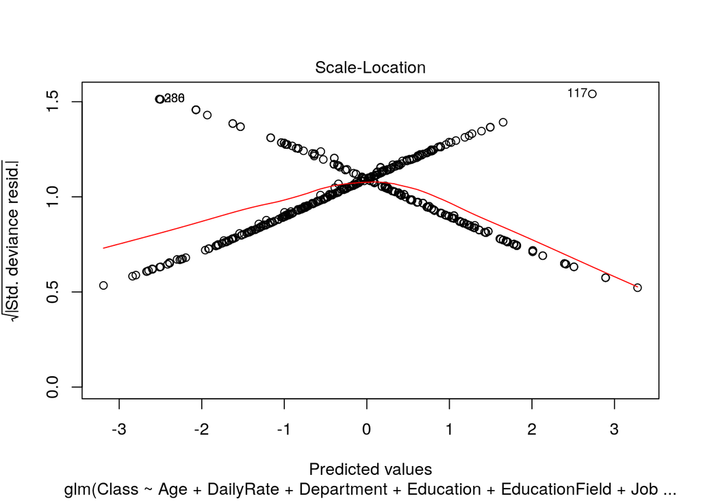

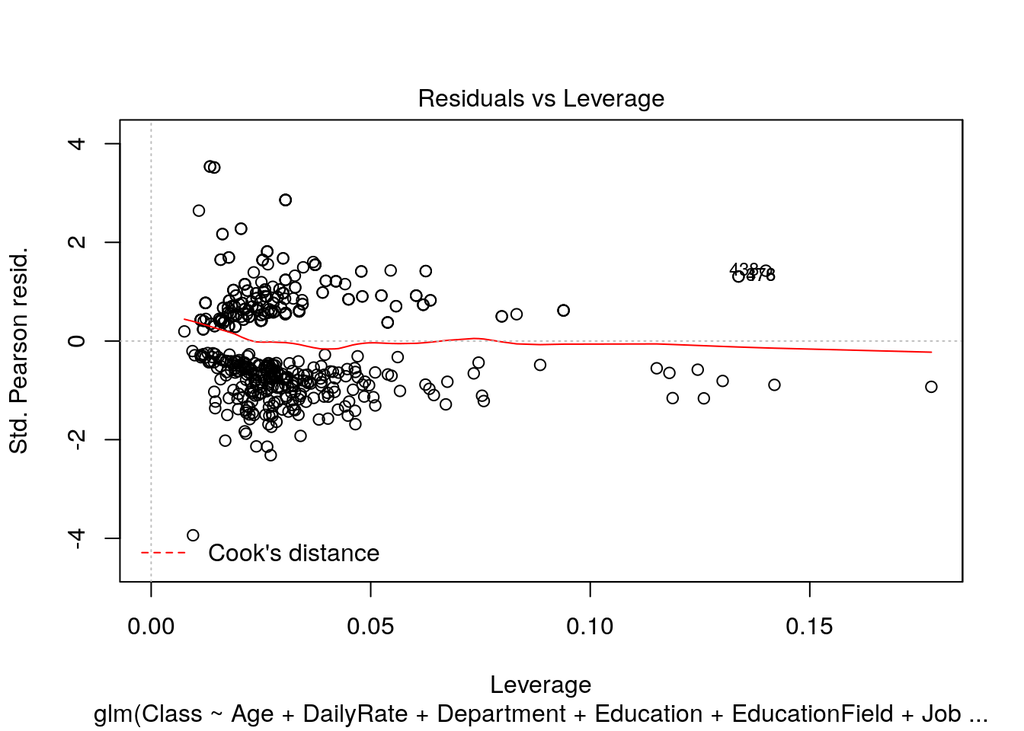

```r
#looking at outliers
plot(main.logr_l_3)
```

```r
#making confusion matrix for how well model did in training
pred = main.logr_l_3$fitted.values

case_study2_sample_train['Pred_Out'] = as.factor(ifelse(pred>.50, "Yes", "No"))

Truth = case_study2_sample_train$Class
Predt = case_study2_sample_train$Pred_Out

confusionMatrix(table(Predt, Truth))
```

```
## Confusion Matrix and Statistics
##
##      Truth
## Predt  No Yes
##   No  173  70
##   Yes  83 186
##
##                Accuracy : 0.7012
##                  95% CI : (0.6595, 0.7405)
##     No Information Rate : 0.5
##     P-Value [Acc > NIR] : <2e-16
##
##                   Kappa : 0.4023
##
##  Mcnemar's Test P-Value : 0.332
##
##             Sensitivity : 0.6758
##             Specificity : 0.7266
##          Pos Pred Value : 0.7119
##          Neg Pred Value : 0.6914
##              Prevalence : 0.5000
##          Detection Rate : 0.3379
##    Detection Prevalence : 0.4746
##       Balanced Accuracy : 0.7012
##
##        'Positive' Class : No
##
```

```r
#testing model on independent test split
pred = predict(main.logr_l_3, newdata = case_study2_sample_test, type="response")

case_study2_sample_test['Pred_Out'] = as.factor(ifelse(pred>.50, "Yes", "No"))

Truth = case_study2_sample_test$Class
Predt = case_study2_sample_test$Pred_Out

confusionMatrix(table(Predt, Truth))
```

```
## Confusion Matrix and Statistics
##
##      Truth
## Predt  No Yes
##   No  318 152
##   Yes 156 322
##
##                Accuracy : 0.6751
##                  95% CI : (0.6443, 0.7049)
##     No Information Rate : 0.5
##     P-Value [Acc > NIR] : <2e-16
##
##                   Kappa : 0.3502
##
##  Mcnemar's Test P-Value : 0.8643
##
##             Sensitivity : 0.6709
##             Specificity : 0.6793
##          Pos Pred Value : 0.6766
##          Neg Pred Value : 0.6736
##              Prevalence : 0.5000
##          Detection Rate : 0.3354
##    Detection Prevalence : 0.4958
##       Balanced Accuracy : 0.6751
##
##        'Positive' Class : No
##
```

**Recommended Logistic Regression Model** **As confirmed by the EDA, we see Job Role, Job Level and Distance from Home are statistically significant in predicting attrition pvalue < 0.05**

```r
#Repeating same steps as from above with more predictors and complexity


main.logr_l_4 = glm(Class ~ Age + DailyRate + Department + Education +
    EducationField + JobLevel + JobSatisfaction + MaritalStatus +
    YearsInCurrentRole + OverTime + JobRole + JobInvolvement +
    YearsSinceLastPromotion + EnvironmentSatisfaction + DistanceFromHome +
    NumCompaniesWorked + WorkLifeBalance + PerformanceRating +
    HourlyRate + TotalWorkingYears + YearsAtCompany + MonthlyIncome +
    BusinessTravel + YearsWithCurrManager + RelationshipSatisfaction +
    PercentSalaryHike + EmployeeNumber, data=case_study2_sample_train ,family=binomial(link='logit') )

step(main.logr_l_4,
     scope = list(upper=main.logr),
     direction="forward",
     test="Chisq",
     data=case_study2_sample_train)
```

```
## Start:  AIC=467.02
## Class ~ Age + DailyRate + Department + Education + EducationField +
##     JobLevel + JobSatisfaction + MaritalStatus + YearsInCurrentRole +
##     OverTime + JobRole + JobInvolvement + YearsSinceLastPromotion +
##     EnvironmentSatisfaction + DistanceFromHome + NumCompaniesWorked +
##     WorkLifeBalance + PerformanceRating + HourlyRate + TotalWorkingYears +
##     YearsAtCompany + MonthlyIncome + BusinessTravel + YearsWithCurrManager +
##     RelationshipSatisfaction + PercentSalaryHike + EmployeeNumber
##
##                         Df Deviance    AIC     LRT Pr(>Chi)
## + TrainingTimesLastYear  1   362.08 448.08 20.9435 4.73e-06 ***
## + MonthlyRate            1   380.02 466.02  3.0014  0.08319 .
## + StockOptionLevel       1   380.29 466.29  2.7364  0.09809 .
## + Gender                 1   380.98 466.98  2.0442  0.15279
## <none>                       383.02 467.02
## ---
## Signif. codes:  0 '***' 0.001 '**' 0.01 '*' 0.05 '.' 0.1 ' ' 1
##
## Step:  AIC=448.08
## Class ~ Age + DailyRate + Department + Education + EducationField +
##     JobLevel + JobSatisfaction + MaritalStatus + YearsInCurrentRole +
##     OverTime + JobRole + JobInvolvement + YearsSinceLastPromotion +
##     EnvironmentSatisfaction + DistanceFromHome + NumCompaniesWorked +
##     WorkLifeBalance + PerformanceRating + HourlyRate + TotalWorkingYears +
##     YearsAtCompany + MonthlyIncome + BusinessTravel + YearsWithCurrManager +
##     RelationshipSatisfaction + PercentSalaryHike + EmployeeNumber +
##     TrainingTimesLastYear
##
##                    Df Deviance    AIC    LRT Pr(>Chi)
## + Gender            1   358.08 446.08 4.0040  0.04539 *
## + MonthlyRate       1   358.57 446.57 3.5124  0.06091 .
## + StockOptionLevel  1   358.68 446.68 3.4009  0.06516 .
## <none>                  362.08 448.08
## ---
## Signif. codes:  0 '***' 0.001 '**' 0.01 '*' 0.05 '.' 0.1 ' ' 1
##
## Step:  AIC=446.08
## Class ~ Age + DailyRate + Department + Education + EducationField +
##     JobLevel + JobSatisfaction + MaritalStatus + YearsInCurrentRole +
##     OverTime + JobRole + JobInvolvement + YearsSinceLastPromotion +
```

[output cut: 11 more lines]

```
## Signif. codes:  0 '***' 0.001 '**' 0.01 '*' 0.05 '.' 0.1 ' ' 1
##
## Step:  AIC=444.13
## Class ~ Age + DailyRate + Department + Education + EducationField +
##     JobLevel + JobSatisfaction + MaritalStatus + YearsInCurrentRole +
##     OverTime + JobRole + JobInvolvement + YearsSinceLastPromotion +
##     EnvironmentSatisfaction + DistanceFromHome + NumCompaniesWorked +
##     WorkLifeBalance + PerformanceRating + HourlyRate + TotalWorkingYears +
##     YearsAtCompany + MonthlyIncome + BusinessTravel + YearsWithCurrManager +
##     RelationshipSatisfaction + PercentSalaryHike + EmployeeNumber +
##     TrainingTimesLastYear + Gender + StockOptionLevel
##
##               Df Deviance    AIC    LRT Pr(>Chi)
## <none>             354.13 444.13
## + MonthlyRate  1   352.25 444.25 1.8786   0.1705
```

```
##
## Call:  glm(formula = Class ~ Age + DailyRate + Department + Education +
##     EducationField + JobLevel + JobSatisfaction + MaritalStatus +
##     YearsInCurrentRole + OverTime + JobRole + JobInvolvement +
##     YearsSinceLastPromotion + EnvironmentSatisfaction + DistanceFromHome +
##     NumCompaniesWorked + WorkLifeBalance + PerformanceRating +
##     HourlyRate + TotalWorkingYears + YearsAtCompany + MonthlyIncome +
##     BusinessTravel + YearsWithCurrManager + RelationshipSatisfaction +
##     PercentSalaryHike + EmployeeNumber + TrainingTimesLastYear +
##     Gender + StockOptionLevel, family = binomial(link = "logit"),
##     data = case_study2_sample_train)
##
## Coefficients:
##                      (Intercept)                               Age
##                       -9.231e+00                        -3.824e-02
##                        DailyRate  DepartmentResearch & Development
##                       -7.309e-04                         1.419e+01
##                  DepartmentSales                         Education
##                        1.532e+01                         7.411e-02
##      EducationFieldLife Sciences           EducationFieldMarketing
##                       -3.666e+00                        -4.614e+00
##            EducationFieldMedical               EducationFieldOther
##                       -3.671e+00                        -3.382e+00
##   EducationFieldTechnical Degree                          JobLevel
##                       -2.569e+00                         1.005e+00
##                  JobSatisfaction              MaritalStatusMarried
##                       -6.863e-01                         9.867e-01
##              MaritalStatusSingle                YearsInCurrentRole
##                        2.025e+00                        -3.315e-01
##                      OverTimeYes            JobRoleHuman Resources
##                        2.719e+00                         1.612e+01
##     JobRoleLaboratory Technician                    JobRoleManager
##                        2.647e+00                         2.590e-01
##    JobRoleManufacturing Director          JobRoleResearch Director
##                       -3.703e-01                         1.101e-01
##        JobRoleResearch Scientist            JobRoleSales Executive
##                        1.731e+00                         1.240e+00
##      JobRoleSales Representative                    JobInvolvement
##                        3.435e+00                        -7.281e-01
##          YearsSinceLastPromotion           EnvironmentSatisfaction
```

[output cut: 8 more lines]

```
##                        1.664e-01                        -6.365e-05
##  BusinessTravelTravel_Frequently       BusinessTravelTravel_Rarely
##                        1.723e+00                         1.707e+00
##             YearsWithCurrManager          RelationshipSatisfaction
##                       -2.121e-01                        -2.991e-01
##                PercentSalaryHike                    EmployeeNumber
##                       -7.092e-02                        -2.420e-04
##            TrainingTimesLastYear                        GenderMale
##                       -5.739e-01                        -6.684e-01
##                 StockOptionLevel
##                        4.174e-01
##
## Degrees of Freedom: 511 Total (i.e. Null);  467 Residual
## Null Deviance:       709.8
## Residual Deviance: 354.1     AIC: 444.1
```

```r
main.logr_l_4$aic
```

```
## [1] 467.0248
```

```r
summary(main.logr_l_4)
```

```
##
## Call:
## glm(formula = Class ~ Age + DailyRate + Department + Education +
##     EducationField + JobLevel + JobSatisfaction + MaritalStatus +
##     YearsInCurrentRole + OverTime + JobRole + JobInvolvement +
##     YearsSinceLastPromotion + EnvironmentSatisfaction + DistanceFromHome +
##     NumCompaniesWorked + WorkLifeBalance + PerformanceRating +
##     HourlyRate + TotalWorkingYears + YearsAtCompany + MonthlyIncome +
##     BusinessTravel + YearsWithCurrManager + RelationshipSatisfaction +
##     PercentSalaryHike + EmployeeNumber, family = binomial(link = "logit"),
##     data = case_study2_sample_train)
##
## Deviance Residuals:
##     Min       1Q   Median       3Q      Max
## -2.5983  -0.5538   0.0311   0.5591   3.0470
##
## Coefficients:
##                                    Estimate Std. Error z value Pr(>|z|)
## (Intercept)                      -1.256e+01  6.991e+02  -0.018 0.985670
## Age                              -3.741e-02  2.133e-02  -1.754 0.079427 .
## DailyRate                        -6.042e-04  3.604e-04  -1.676 0.093662 .
## DepartmentResearch & Development  1.401e+01  6.991e+02   0.020 0.984015
## DepartmentSales                   1.513e+01  6.991e+02   0.022 0.982732
## Education                         6.191e-02  1.470e-01   0.421 0.673696
## EducationFieldLife Sciences      -2.527e+00  1.491e+00  -1.695 0.090032 .
## EducationFieldMarketing          -2.960e+00  1.530e+00  -1.936 0.052922 .
## EducationFieldMedical            -2.642e+00  1.489e+00  -1.774 0.076120 .
## EducationFieldOther              -2.472e+00  1.533e+00  -1.612 0.106917
## EducationFieldTechnical Degree   -1.638e+00  1.480e+00  -1.107 0.268474
## JobLevel                          1.212e+00  5.161e-01   2.349 0.018838 *
## JobSatisfaction                  -5.834e-01  1.267e-01  -4.603 4.16e-06 ***
## MaritalStatusMarried              9.307e-01  3.898e-01   2.388 0.016950 *
## MaritalStatusSingle               1.491e+00  4.056e-01   3.677 0.000236 ***
## YearsInCurrentRole               -2.524e-01  7.813e-02  -3.231 0.001235 **
## OverTimeYes                       2.504e+00  3.176e-01   7.882 3.23e-15 ***
## JobRoleHuman Resources            1.596e+01  6.991e+02   0.023 0.981784
## JobRoleLaboratory Technician      2.346e+00  7.993e-01   2.935 0.003332 **
## JobRoleManager                    1.055e-01  1.307e+00   0.081 0.935637
## JobRoleManufacturing Director    -2.435e-01  8.489e-01  -0.287 0.774194
## JobRoleResearch Director          5.786e-01  1.178e+00   0.491 0.623383
```

[output cut: 15 more lines]

```
## BusinessTravelTravel_Rarely       1.663e+00  5.061e-01   3.286 0.001016 **
## YearsWithCurrManager             -1.793e-01  6.763e-02  -2.651 0.008035 **
## RelationshipSatisfaction         -2.296e-01  1.280e-01  -1.793 0.072957 .
## PercentSalaryHike                -6.159e-02  6.170e-02  -0.998 0.318160
## EmployeeNumber                   -7.467e-05  2.378e-04  -0.314 0.753486
## ---
## Signif. codes:  0 '***' 0.001 '**' 0.01 '*' 0.05 '.' 0.1 ' ' 1
##
## (Dispersion parameter for binomial family taken to be 1)
##
##     Null deviance: 709.78  on 511  degrees of freedom
## Residual deviance: 383.02  on 470  degrees of freedom
## AIC: 467.02
##
## Number of Fisher Scoring iterations: 14
```

```r
exp(cbind("Odds ratio" = coef(main.logr_l_4), confint.default(main.logr_l_4, level = 0.95)))
```

```
##                                    Odds ratio       2.5 %      97.5 %
## (Intercept)                      3.521858e-06 0.000000000         Inf
## Age                              9.632813e-01 0.923844038   1.0044021
## DailyRate                        9.993960e-01 0.998690348   1.0001022
## DepartmentResearch & Development 1.210729e+06 0.000000000         Inf
## DepartmentSales                  3.726553e+06 0.000000000         Inf
## Education                        1.063864e+00 0.797521161   1.4191550
## EducationFieldLife Sciences      7.987671e-02 0.004299676   1.4838999
## EducationFieldMarketing          5.179604e-02 0.002584527   1.0380352
## EducationFieldMedical            7.124058e-02 0.003845429   1.3198061
## EducationFieldOther              8.445432e-02 0.004185165   1.7042417
## EducationFieldTechnical Degree   1.944032e-01 0.010687233   3.5362367
## JobLevel                         3.361067e+00 1.222198615   9.2429917
## JobSatisfaction                  5.580208e-01 0.435288184   0.7153587
## MaritalStatusMarried             2.536234e+00 1.181461991   5.4445099
## MaritalStatusSingle              4.442803e+00 2.006326068   9.8381326
## YearsInCurrentRole               7.769378e-01 0.666630400   0.9054978
## OverTimeYes                      1.222537e+01 6.559763249  22.7843266
## JobRoleHuman Resources           8.553201e+06 0.000000000         Inf
## JobRoleLaboratory Technician     1.044516e+01 2.180593117  50.0329111
## JobRoleManager                   1.111298e+00 0.085800240  14.3937074
## JobRoleManufacturing Director    7.838565e-01 0.148488919   4.1378909
## JobRoleResearch Director         1.783541e+00 0.177150321  17.9566012
## JobRoleResearch Scientist        6.785816e+00 1.422640161  32.3674918
## JobRoleSales Executive           2.235629e+00 0.146107842  34.2078536
## JobRoleSales Representative      2.004119e+01 1.002124000 400.7981499
## JobInvolvement                   4.957622e-01 0.337968826   0.7272275
## YearsSinceLastPromotion          1.339429e+00 1.179465404   1.5210884
## EnvironmentSatisfaction          7.196927e-01 0.557719071   0.9287071
## DistanceFromHome                 1.050260e+00 1.015987597   1.0856895
## NumCompaniesWorked               1.329569e+00 1.167533015   1.5140921
## WorkLifeBalance                  5.120682e-01 0.365278299   0.7178468
## PerformanceRating                2.311186e+00 0.600932204   8.8888279
## HourlyRate                       1.009145e+00 0.994823013   1.0236740
## TotalWorkingYears                9.066481e-01 0.821661616   1.0004250
## YearsAtCompany                   1.111548e+00 1.006349092   1.2277438
## MonthlyIncome                    9.998771e-01 0.999601135   1.0001531
## BusinessTravelTravel_Frequently  5.205114e+00 1.696250251  15.9724140
## BusinessTravelTravel_Rarely      5.275062e+00 1.956366760  14.2234484
## YearsWithCurrManager             8.358897e-01 0.732120627   0.9543667
## RelationshipSatisfaction         7.948551e-01 0.618439219   1.0215954
## PercentSalaryHike                9.402671e-01 0.833167989   1.0611333
## EmployeeNumber                   9.999253e-01 0.999459444   1.0003914
```

```r
coefficients(main.logr_l_4)
```

```
##                      (Intercept)                              Age
##                    -1.255652e+01                    -3.740979e-02
##                        DailyRate DepartmentResearch & Development
##                    -6.041560e-04                     1.400673e+01
##                  DepartmentSales                        Education
##                     1.513099e+01                     6.190735e-02
##      EducationFieldLife Sciences          EducationFieldMarketing
##                    -2.527271e+00                    -2.960442e+00
##            EducationFieldMedical              EducationFieldOther
##                    -2.641693e+00                    -2.471544e+00
##   EducationFieldTechnical Degree                         JobLevel
##                    -1.637821e+00                     1.212258e+00
##                  JobSatisfaction             MaritalStatusMarried
##                    -5.833591e-01                     9.306802e-01
##              MaritalStatusSingle               YearsInCurrentRole
##                     1.491286e+00                    -2.523950e-01
##                      OverTimeYes           JobRoleHuman Resources
##                     2.503514e+00                     1.596182e+01
##     JobRoleLaboratory Technician                   JobRoleManager
##                     2.346139e+00                     1.055288e-01
##    JobRoleManufacturing Director         JobRoleResearch Director
##                    -2.435294e-01                     5.786006e-01
##        JobRoleResearch Scientist           JobRoleSales Executive
##                     1.914834e+00                     8.045225e-01
##      JobRoleSales Representative                   JobInvolvement
##                     2.997790e+00                    -7.016588e-01
##          YearsSinceLastPromotion          EnvironmentSatisfaction
##                     2.922437e-01                    -3.289309e-01
##                 DistanceFromHome               NumCompaniesWorked
##                     4.903820e-02                     2.848545e-01
##                  WorkLifeBalance                PerformanceRating
##                    -6.692974e-01                     8.377610e-01
##                       HourlyRate                TotalWorkingYears
##                     9.103840e-03                    -9.800088e-02
##                   YearsAtCompany                    MonthlyIncome
##                     1.057536e-01                    -1.229319e-04
##  BusinessTravelTravel_Frequently      BusinessTravelTravel_Rarely
##                     1.649642e+00                     1.662990e+00
##             YearsWithCurrManager         RelationshipSatisfaction
##                    -1.792587e-01                    -2.295954e-01
##                PercentSalaryHike                   EmployeeNumber
##                    -6.159125e-02                    -7.467208e-05
```

```r
#based on the goodness of fit test, we see this model is a good fit for the data
hoslem.test(main.logr_l_4$y, fitted(main.logr_l_4), g=10)
```

```
##
##  Hosmer and Lemeshow goodness of fit (GOF) test
##
## data:  main.logr_l_4$y, fitted(main.logr_l_4)
## X-squared = 10.401, df = 8, p-value = 0.238
```

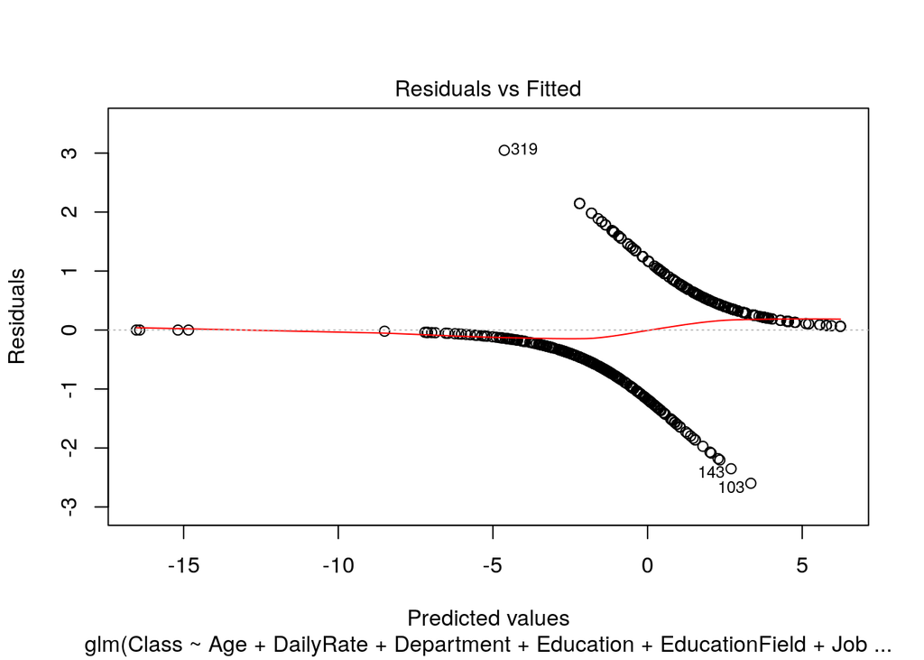

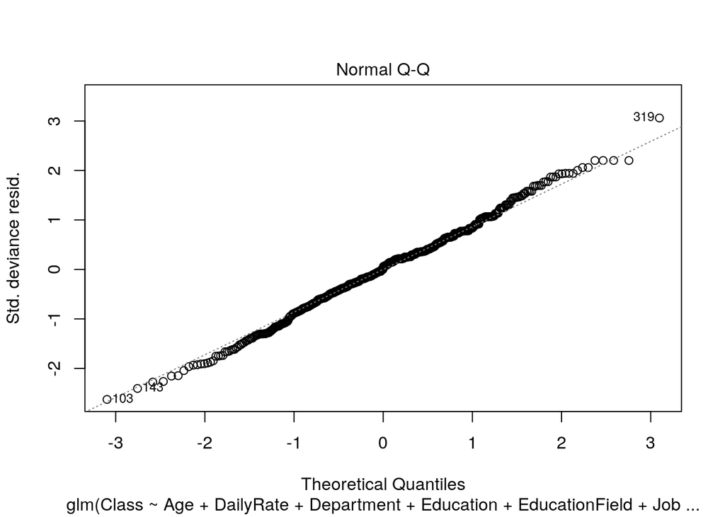

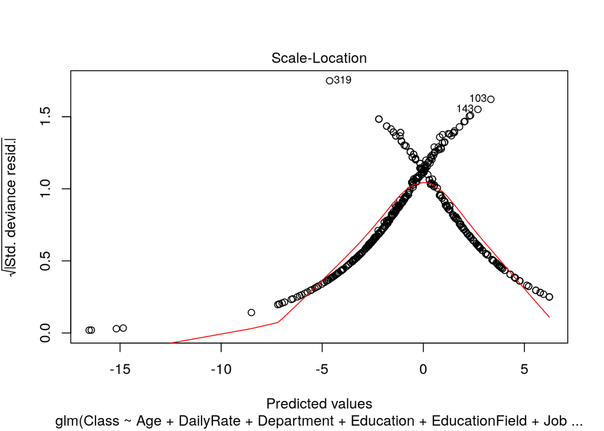

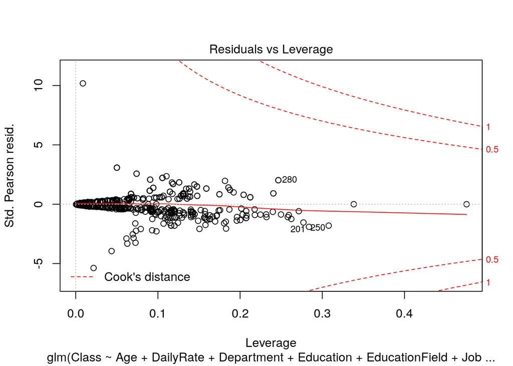

```r
plot(main.logr_l_4)
```

```r
pred = main.logr_l_4$fitted.values

case_study2_sample_train['Pred_Out'] = as.factor(ifelse(pred>.50, "Yes", "No"))

Truth = case_study2_sample_train$Class
Predt = case_study2_sample_train$Pred_Out

confusionMatrix(table(Predt, Truth))
```

```
## Confusion Matrix and Statistics
##
##      Truth
## Predt  No Yes
##   No  207  44
##   Yes  49 212
##
##                Accuracy : 0.8184
##                  95% CI : (0.7822, 0.8508)
##     No Information Rate : 0.5
##     P-Value [Acc > NIR] : <2e-16
##
##                   Kappa : 0.6367
##
##  Mcnemar's Test P-Value : 0.6783
##
##             Sensitivity : 0.8086
##             Specificity : 0.8281
##          Pos Pred Value : 0.8247
##          Neg Pred Value : 0.8123
##              Prevalence : 0.5000
##          Detection Rate : 0.4043
##    Detection Prevalence : 0.4902
##       Balanced Accuracy : 0.8184
##
##        'Positive' Class : No
##
```

```r
pred = predict(main.logr_l_4, newdata = case_study2_sample_test, type="response")

case_study2_sample_test['Pred_Out'] = as.factor(ifelse(pred>.50, "Yes", "No"))

Truth = case_study2_sample_test$Class
Predt = case_study2_sample_test$Pred_Out

confusionMatrix(table(Predt, Truth))
```

```
## Confusion Matrix and Statistics
##
##      Truth
## Predt  No Yes
##   No  368 101
##   Yes 106 373
##
##                Accuracy : 0.7816
##                  95% CI : (0.754, 0.8076)
##     No Information Rate : 0.5
##     P-Value [Acc > NIR] : <2e-16
##
##                   Kappa : 0.5633
##
##  Mcnemar's Test P-Value : 0.781
##
##             Sensitivity : 0.7764
##             Specificity : 0.7869
##          Pos Pred Value : 0.7846
##          Neg Pred Value : 0.7787
##              Prevalence : 0.5000
##          Detection Rate : 0.3882
##    Detection Prevalence : 0.4947
##       Balanced Accuracy : 0.7816
##
##        'Positive' Class : No
##
```

```r
case_study_att_pred = predict(main.logr_l_4, newdata = case_study_attrition_preds, type="response")

case_study_attrition_preds['Attrition'] = as.factor(ifelse(case_study_att_pred>.50, "Yes", "No"))

case_study_attrition_preds_out = case_study_attrition_preds[,c('ID','Attrition')]

head(case_study_attrition_preds_out)
```

```
##     ID Attrition
## 1 1171        No
## 2 1172        No
## 3 1173        No
## 4 1174        No
## 5 1175        No
## 6 1176        No
```

**We see from the mcnemar test pvalue = 0.003 < .05 the Logistic Regression is significantly different from the NB model, outperforming the NB model**

```r
#Constructing a performance metric comparison matrix for mcnemar testing to see if NB is different from the performance of the logistic regression model

performance_comp_mat = matrix(c(384,564, 469, 479), nrow = 2, dimnames = list("NB" = c("No", "Yes"), "LogR"= c("No", "Yes")))

mcnemar.test(performance_comp_mat)
```

```
##
##  McNemar's Chi-squared test with continuity correction
##
## data:  performance_comp_mat
## McNemar's chi-squared = 8.5537, df = 1, p-value = 0.003448
```